# Mine Basin Regressions

Lukas Vashold

2024-08-14

## Description

This Markdown contains preliminary results for RDD regressions of mines and their effects on agricultural productivity. The structure of the document is as follows:

- Main models
  - Plain inclusion of downstream indicator
  - Interaction of downstream indicator with order factor
  - Interaction of downstream indicator with distance measure
  - Interaction of downstream indicator with distance bin measure
- Robustness
  - Controls sequentially added
  - Mean EVI instead of Max EVI
  - Varying fixed effects (higher order basins, countries, regions)
  - Excluding mine basins
- Heterogeneity
  - By biome (forests, deserts, grasslands)
  - By region (North & East Africa, West Africa, Southern Africa)
  - By primary crop (to-do)
- Plots
  - RD plot with distance
  - Coef plot with ordering

This specification includes:

- years from **2016 to 2023**
- basin systems with area mined of at least **0 square km**
- up/downstream basins up to **10** basins “away”
- the mine basin is **included as downstream**
- mine basins that have at least **0** up/downstream basin(s)

## Main Models

### No interaction

```
##                              mod2_noint_restr..1 mod4_noint_restr[1].1
## Dependent Var.:                          max_EVI               max_EVI
##
## downstream                   -0.0083*** (0.0020)   -0.0066*** (0.0019)
## elevation                                         -2.03e-5*** (5.9e-6)
## slope                                               0.0032*** (0.0005)
## tmp_max                                            -0.0054*** (0.0007)
## precipitation                                       3.3e-5*** (3.6e-6)
## accessibility_to_cities_2015                        -9.41e-6. (5.5e-6)
## pop_2015                                         -1.51e-7*** (2.75e-8)
## Fixed-Effects:               ------------------- ---------------------
## year                                         Yes                   Yes
## as.factor(mine_basin)                        Yes                   Yes
## ____________________________ ___________________ _____________________
## S.E.: Clustered                   by: mine_basin        by: mine_basin
## Observations                             114,616               114,496
## R2                                       0.91800               0.92389
## Within R2                                0.00293               0.05514
##
##                              mod2_noint_res..1 mod4_noint_restr[2].1
## Dependent Var.:                   max_c_EVI_af          max_c_EVI_af
##
## downstream                   -0.0049* (0.0024)    -0.0063** (0.0024)
## elevation                                      -4.08e-5*** (6.79e-6)
## slope                                             0.0023*** (0.0006)
## tmp_max                                          -0.0071*** (0.0007)
## precipitation                                   2.87e-5*** (3.92e-6)
## accessibility_to_cities_2015                      -3.53e-7 (1.15e-5)
## pop_2015                                        -1.1e-7*** (2.01e-8)
## Fixed-Effects:               ----------------- ---------------------
## year                                       Yes                   Yes
## as.factor(mine_basin)                      Yes                   Yes
## ____________________________ _________________ _____________________
## S.E.: Clustered                 by: mine_basin        by: mine_basin
## Observations                            94,671                94,604
## R2                                     0.77955               0.78575
## Within R2                              0.00065               0.02428
##
##                              mod2_noint_re..1 mod4_noint_restr[3].1
## Dependent Var.:                 max_c_EVI_ESA         max_c_EVI_ESA
```

[output cut: 22 more lines]

```
## slope                                                   -31.30 (123.4)
## tmp_max                                              -608.9*** (112.7)
## precipitation                                          1.501* (0.6103)
## accessibility_to_cities_2015                             2.454 (4.356)
## pop_2015                                              -0.0034 (0.0038)
## Fixed-Effects:               -------------------- --------------------
## year                                          Yes                  Yes
## as.factor(mine_basin)                         Yes                  Yes
## ____________________________ ____________________ ____________________
## S.E.: Clustered                    by: mine_basin       by: mine_basin
## Observations                                6,295                6,289
## R2                                        0.73241              0.76668
## Within R2                                 0.00370              0.13186
## ---
## Signif. codes: 0 '***' 0.001 '**' 0.01 '*' 0.05 '.' 0.1 ' ' 1
```

Compared to the sample mean, the presence of a mine upstream changes

- the overall EVI by **-2.01%**, p-value = *0* (-1.6%, p-value = *0*)
- the croplands EVI (based on Africover mask) by **-1.07%**, p-value = *0.039* (-1.38%, p-value = *0.009*)
- the croplands EVI (based on ESA mask) by **-0.7%**, p-value = *0.235* (-0.71%, p-value = *0.215*)
- the yield of croplands (based on ESA productivity measure) by **-3.26%**, p-value = *0.133* (1.37%, p-value = *0.529*)

on average **without** (with) controls.

### Order (factor) interaction

```
##                                    mod2_order_restr..1 mod4_order_restr[1].1
## Dependent Var.:                                max_EVI               max_EVI
##
## downstream x as.factor(order) = 0  -0.0071*** (0.0016)   -0.0064*** (0.0016)
## downstream x as.factor(order) = 1  -0.0067*** (0.0020)    -0.0061** (0.0020)
## downstream x as.factor(order) = 2  -0.0077*** (0.0023)    -0.0069** (0.0023)
## downstream x as.factor(order) = 3  -0.0101*** (0.0025)   -0.0086*** (0.0025)
## downstream x as.factor(order) = 4   -0.0078** (0.0026)     -0.0062* (0.0026)
## downstream x as.factor(order) = 5   -0.0084** (0.0029)     -0.0059* (0.0028)
## downstream x as.factor(order) = 6   -0.0091** (0.0031)     -0.0058* (0.0030)
## downstream x as.factor(order) = 7   -0.0100** (0.0034)     -0.0065* (0.0033)
## downstream x as.factor(order) = 8  -0.0147*** (0.0034)   -0.0111*** (0.0033)
## downstream x as.factor(order) = 9   -0.0110** (0.0036)     -0.0068. (0.0035)
## downstream x as.factor(order) = 10  -0.0114** (0.0038)      -0.0057 (0.0039)
## elevation                                              -2.08e-5*** (6.24e-6)
## slope                                                     0.0032*** (0.0005)
## tmp_max                                                  -0.0054*** (0.0007)
## precipitation                                            3.3e-5*** (3.59e-6)
## accessibility_to_cities_2015                             -9.16e-6. (5.49e-6)
## pop_2015                                               -1.51e-7*** (2.76e-8)
## Fixed-Effects:                     ------------------- ---------------------
## year                                               Yes                   Yes
## as.factor(mine_basin)                              Yes                   Yes
## __________________________________ ___________________ _____________________
## S.E.: Clustered                         by: mine_basin        by: mine_basin
## Observations                                   114,616               114,496
## R2                                             0.91806               0.92392
## Within R2                                      0.00366               0.05549
##
##                                    mod2_order_restr..1.1 mod4_order_restr[2].1
## Dependent Var.:                             max_c_EVI_af          max_c_EVI_af
##
## downstream x as.factor(order) = 0    -0.0086*** (0.0022)   -0.0087*** (0.0022)
## downstream x as.factor(order) = 1       -0.0041 (0.0026)     -0.0052. (0.0027)
## downstream x as.factor(order) = 2       -0.0035 (0.0029)     -0.0053. (0.0030)
## downstream x as.factor(order) = 3       -0.0042 (0.0032)     -0.0060. (0.0034)
## downstream x as.factor(order) = 4       -0.0020 (0.0035)      -0.0035 (0.0037)
## downstream x as.factor(order) = 5       -0.0002 (0.0037)      -0.0008 (0.0040)
## downstream x as.factor(order) = 6       -0.0035 (0.0039)      -0.0041 (0.0042)
## downstream x as.factor(order) = 7        0.0015 (0.0041)       0.0010 (0.0044)
```

[output cut: 62 more lines]

```
## slope                                                         -44.92 (121.6)
## tmp_max                                                    -612.9*** (112.9)
## precipitation                                                1.421* (0.5793)
## accessibility_to_cities_2015                                   1.345 (4.601)
## pop_2015                                                    -0.0026 (0.0034)
## Fixed-Effects:                     -------------------- --------------------
## year                                                Yes                  Yes
## as.factor(mine_basin)                               Yes                  Yes
## __________________________________ ____________________ ____________________
## S.E.: Clustered                          by: mine_basin       by: mine_basin
## Observations                                      6,295                6,289
## R2                                              0.73399              0.76836
## Within R2                                       0.00958              0.13813
## ---
## Signif. codes: 0 '***' 0.001 '**' 0.01 '*' 0.05 '.' 0.1 ' ' 1
```

Compared to the sample mean, the presence of a mine upstream changes

- the overall EVI by **-1.73%**, p-value = *0* (-1.56%, p-value = *0*)
- the croplands EVI (based on Africover mask) by **-1.88%**, p-value = *0* (-1.91%, p-value = *0*)
- the croplands EVI (based on ESA mask) by **-1.19%**, p-value = *0.031* (-0.98%, p-value = *0.074*)
- the yield of croplands (based on ESA productivity measure) by **-3.57%**, p-value = *0.071* (-0.22%, p-value = *0.903*)

on average **without** (with) controls.

### Distance interaction

```
##                              mod2_dist_restr..1  mod4_dist_restr[1].1
## Dependent Var.:                         max_EVI               max_EVI
##
## distance                      4.05e-5 (9.03e-5)     2.56e-5 (8.19e-5)
## distance square              -1.87e-7 (6.27e-7)      2.1e-8 (5.56e-7)
## downstream                   -0.0065** (0.0023)    -0.0058** (0.0021)
## distance x downstream         -2.02e-5 (0.0001)     -2.02e-5 (0.0001)
## I(distance^2) x downstream   -3.98e-7 (9.17e-7)     -9.8e-8 (7.19e-7)
## elevation                                       -2.22e-5*** (6.71e-6)
## slope                                              0.0032*** (0.0005)
## tmp_max                                           -0.0053*** (0.0007)
## precipitation                                     3.33e-5*** (3.6e-6)
## accessibility_to_cities_2015                      -1.01e-5. (5.31e-6)
## pop_2015                                        -1.51e-7*** (2.77e-8)
## Fixed-Effects:               ------------------ ---------------------
## year                                        Yes                   Yes
## as.factor(mine_basin)                       Yes                   Yes
## ____________________________ __________________ _____________________
## S.E.: Clustered                  by: mine_basin        by: mine_basin
## Observations                            114,616               114,496
## R2                                      0.91804               0.92390
## Within R2                               0.00346               0.05524
##
##                              mod2_dist_restr[..1  mod4_dist_restr[2].1
## Dependent Var.:                     max_c_EVI_af          max_c_EVI_af
##
## distance                       -7.01e-5 (0.0001)      -4.6e-5 (0.0001)
## distance square                6.93e-7 (8.38e-7)     6.06e-7 (8.22e-7)
## downstream                    -0.0086** (0.0029)    -0.0087** (0.0028)
## distance x downstream           0.0003* (0.0001)       0.0002 (0.0001)
## I(distance^2) x downstream   -2.15e-6* (1.06e-6)   -1.94e-6. (1.03e-6)
## elevation                                        -4.03e-5*** (7.61e-6)
## slope                                               0.0023*** (0.0006)
## tmp_max                                            -0.0070*** (0.0007)
## precipitation                                     2.88e-5*** (3.94e-6)
## accessibility_to_cities_2015                        -4.03e-6 (1.19e-5)
## pop_2015                                         -1.06e-7*** (2.03e-8)
## Fixed-Effects:               ------------------- ---------------------
## year                                         Yes                   Yes
## as.factor(mine_basin)                        Yes                   Yes
```

[output cut: 38 more lines]

```
## slope                                                   -84.54 (109.6)
## tmp_max                                              -626.1*** (113.7)
## precipitation                                          1.400* (0.5738)
## accessibility_to_cities_2015                           -0.0268 (4.882)
## pop_2015                                              -0.0028 (0.0034)
## Fixed-Effects:               -------------------- --------------------
## year                                          Yes                  Yes
## as.factor(mine_basin)                         Yes                  Yes
## ____________________________ ____________________ ____________________
## S.E.: Clustered                    by: mine_basin       by: mine_basin
## Observations                                6,295                6,289
## R2                                        0.73792              0.76887
## Within R2                                 0.02420              0.14002
## ---
## Signif. codes: 0 '***' 0.001 '**' 0.01 '*' 0.05 '.' 0.1 ' ' 1
```

Compared to the sample mean, the presence of a mine upstream changes

- the overall EVI by **-1.59%**, p-value = *0.005* (-1.42%, p-value = *0.005*)
- the croplands EVI (based on Africover mask) by **-1.9%**, p-value = *0.003* (-1.92%, p-value = *0.002*)
- the croplands EVI (based on ESA mask) by **-1.15%**, p-value = *0.114* (-1.07%, p-value = *0.138*)
- the yield of croplands (based on ESA productivity measure) by **0.9%**, p-value = *0.743* (1.81%, p-value = *0.407*)

on average **without** (with) controls.

### Distance bin interaction

```
##                                   mod2_dist_bin_r..1 mod4_dist_bin_rest..1
## Dependent Var.:                              max_EVI               max_EVI
##
## distance_bin(10,20]                 -0.0012 (0.0025)      -0.0012 (0.0025)
## distance_bin(20,30]                  0.0005 (0.0026)       0.0007 (0.0026)
## distance_bin(30,40]                  0.0014 (0.0028)       0.0008 (0.0028)
## distance_bin(40,50]                  0.0015 (0.0030)       0.0016 (0.0031)
## distance_bin(50,Inf]                 0.0013 (0.0033)       0.0014 (0.0033)
## downstream                        -0.0070** (0.0023)    -0.0063** (0.0023)
## distance_bin(10,20] x downstream     0.0008 (0.0030)       0.0006 (0.0030)
## distance_bin(20,30] x downstream    -0.0002 (0.0032)      4.76e-5 (0.0032)
## distance_bin(30,40] x downstream    -0.0030 (0.0034)      -0.0008 (0.0035)
## distance_bin(40,50] x downstream    -0.0032 (0.0040)      -0.0007 (0.0037)
## distance_bin(50,Inf] x downstream   -0.0033 (0.0040)      -0.0011 (0.0041)
## elevation                                            -2.11e-5*** (6.38e-6)
## slope                                                   0.0032*** (0.0005)
## tmp_max                                                -0.0053*** (0.0007)
## precipitation                                          3.31e-5*** (3.6e-6)
## accessibility_to_cities_2015                               -1e-5. (5.3e-6)
## pop_2015                                              -1.5e-7*** (2.77e-8)
## Fixed-Effects:                    ------------------ ---------------------
## year                                             Yes                   Yes
## as.factor(mine_basin)                            Yes                   Yes
## _________________________________ __________________ _____________________
## S.E.: Clustered                       by: mine_basin        by: mine_basin
## Observations                                 114,616               114,496
## R2                                           0.91802               0.92391
## Within R2                                    0.00320               0.05529
##
##                                   mod2_dist_bin_..1 mod4_dist_bin_rest..1.1
## Dependent Var.:                        max_c_EVI_af            max_c_EVI_af
##
## distance_bin(10,20]                -0.0031 (0.0038)        -0.0022 (0.0039)
## distance_bin(20,30]                 0.0005 (0.0039)         0.0013 (0.0040)
## distance_bin(30,40]                -0.0014 (0.0043)        -0.0014 (0.0044)
## distance_bin(40,50]                -0.0030 (0.0042)        -0.0020 (0.0043)
## distance_bin(50,Inf]               -0.0011 (0.0042)        9.52e-5 (0.0044)
## downstream                        -0.0087* (0.0035)       -0.0083* (0.0035)
## distance_bin(10,20] x downstream    0.0048 (0.0043)         0.0029 (0.0044)
## distance_bin(20,30] x downstream    0.0037 (0.0046)         0.0016 (0.0047)
```

[output cut: 62 more lines]

```
## slope                                                        -51.03 (119.1)
## tmp_max                                                   -615.6*** (109.7)
## precipitation                                               1.402* (0.6002)
## accessibility_to_cities_2015                                -0.4514 (4.958)
## pop_2015                                                   -0.0028 (0.0035)
## Fixed-Effects:                    -------------------- --------------------
## year                                               Yes                  Yes
## as.factor(mine_basin)                              Yes                  Yes
## _________________________________ ____________________ ____________________
## S.E.: Clustered                         by: mine_basin       by: mine_basin
## Observations                                     6,295                6,289
## R2                                             0.73711              0.76908
## Within R2                                      0.02118              0.14081
## ---
## Signif. codes: 0 '***' 0.001 '**' 0.01 '*' 0.05 '.' 0.1 ' ' 1
```

Compared to the sample mean, the presence of a mine upstream changes

- the overall EVI by **-1.71%**, p-value = *0.002* (-1.53%, p-value = *0.006*)
- the croplands EVI (based on Africover mask) by **-1.91%**, p-value = *0.012* (-1.83%, p-value = *0.018*)
- the croplands EVI (based on ESA mask) by **-0.76%**, p-value = *0.341* (-0.75%, p-value = *0.365*)
- the yield of croplands (based on ESA productivity measure) by **0.5%**, p-value = *0.743* (1.69%, p-value = *0.297*)

on average **without** (with) controls.

## Robustness

### Controls sequentially added

#### Order interaction

```
##                                    mod1_order_contr..1 mod2_order_contr..1
## Dependent Var.:                                max_EVI             max_EVI
##
## downstream x as.factor(order) = 0  -0.0071*** (0.0016) -0.0071*** (0.0016)
## downstream x as.factor(order) = 1  -0.0067*** (0.0020)  -0.0055** (0.0020)
## downstream x as.factor(order) = 2  -0.0077*** (0.0023)  -0.0060** (0.0023)
## downstream x as.factor(order) = 3  -0.0101*** (0.0025)  -0.0076** (0.0025)
## downstream x as.factor(order) = 4   -0.0078** (0.0026)   -0.0059* (0.0026)
## downstream x as.factor(order) = 5   -0.0084** (0.0029)   -0.0057* (0.0028)
## downstream x as.factor(order) = 6   -0.0091** (0.0031)   -0.0060* (0.0030)
## downstream x as.factor(order) = 7   -0.0100** (0.0034)   -0.0068* (0.0033)
## downstream x as.factor(order) = 8  -0.0147*** (0.0034) -0.0115*** (0.0033)
## downstream x as.factor(order) = 9   -0.0110** (0.0036)   -0.0070. (0.0036)
## downstream x as.factor(order) = 10  -0.0114** (0.0038)    -0.0060 (0.0039)
## elevation                                                -5.67e-6 (5.9e-6)
## slope                                                   0.0034*** (0.0005)
## tmp_max
## precipitation
## accessibility_to_cities_2015
## pop_2015
## Fixed-Effects:                     ------------------- -------------------
## year                                               Yes                 Yes
## as.factor(mine_basin)                              Yes                 Yes
## __________________________________ ___________________ ___________________
## S.E.: Clustered                         by: mine_basin      by: mine_basin
## Observations                                   114,616             114,616
## R2                                             0.91806             0.92153
## Within R2                                      0.00366             0.04592
##
##                                    mod3_order_contr[1].1 mod4_order_contr[1].1
## Dependent Var.:                                  max_EVI               max_EVI
##
## downstream x as.factor(order) = 0    -0.0071*** (0.0017)   -0.0064*** (0.0016)
## downstream x as.factor(order) = 1     -0.0058** (0.0020)    -0.0061** (0.0020)
## downstream x as.factor(order) = 2     -0.0063** (0.0023)    -0.0069** (0.0023)
## downstream x as.factor(order) = 3     -0.0078** (0.0025)   -0.0086*** (0.0025)
## downstream x as.factor(order) = 4      -0.0059* (0.0027)     -0.0062* (0.0026)
## downstream x as.factor(order) = 5      -0.0057* (0.0028)     -0.0059* (0.0028)
## downstream x as.factor(order) = 6      -0.0061* (0.0030)     -0.0058* (0.0030)
## downstream x as.factor(order) = 7      -0.0066* (0.0033)     -0.0065* (0.0033)
```

[output cut: 178 more lines]

```
## slope                                      -41.12 (120.6)       -44.92 (121.6)
## tmp_max                                 -610.8*** (113.5)    -612.9*** (112.9)
## precipitation                             1.386* (0.5756)      1.421* (0.5793)
## accessibility_to_cities_2015                                     1.345 (4.601)
## pop_2015                                                      -0.0026 (0.0034)
## Fixed-Effects:                       -------------------- --------------------
## year                                                  Yes                  Yes
## as.factor(mine_basin)                                 Yes                  Yes
## __________________________________   ____________________ ____________________
## S.E.: Clustered                            by: mine_basin       by: mine_basin
## Observations                                        6,295                6,289
## R2                                                0.76833              0.76836
## Within R2                                         0.13744              0.13813
## ---
## Signif. codes: 0 '***' 0.001 '**' 0.01 '*' 0.05 '.' 0.1 ' ' 1
```

#### Distance interaction

```
##                              mod1_dist_contr..1 mod2_dist_contr..1
## Dependent Var.:                         max_EVI            max_EVI
##
## distance                      4.05e-5 (9.03e-5)   2.98e-5 (8.4e-5)
## distance square              -1.87e-7 (6.27e-7) -9.18e-9 (5.68e-7)
## downstream                   -0.0065** (0.0023) -0.0060** (0.0021)
## distance x downstream         -2.02e-5 (0.0001)   1.05e-5 (0.0001)
## I(distance^2) x downstream   -3.98e-7 (9.17e-7) -4.37e-7 (7.35e-7)
## elevation                                       -7.45e-6 (6.56e-6)
## slope                                           0.0034*** (0.0005)
## tmp_max
## precipitation
## accessibility_to_cities_2015
## pop_2015
## Fixed-Effects:               ------------------ ------------------
## year                                        Yes                Yes
## as.factor(mine_basin)                       Yes                Yes
## ____________________________ __________________ __________________
## S.E.: Clustered                  by: mine_basin     by: mine_basin
## Observations                            114,616            114,616
## R2                                      0.91804            0.92152
## Within R2                               0.00346            0.04573
##
##                              mod3_dist_contr[1].1  mod4_dist_contr[1].1
## Dependent Var.:                           max_EVI               max_EVI
##
## distance                        2.82e-5 (8.44e-5)     2.56e-5 (8.19e-5)
## distance square                -3.24e-8 (5.72e-7)      2.1e-8 (5.56e-7)
## downstream                     -0.0061** (0.0021)    -0.0058** (0.0021)
## distance x downstream            9.21e-6 (0.0001)     -2.02e-5 (0.0001)
## I(distance^2) x downstream     -3.41e-7 (7.39e-7)     -9.8e-8 (7.19e-7)
## elevation                    -2.27e-5*** (6.7e-6) -2.22e-5*** (6.71e-6)
## slope                          0.0033*** (0.0005)    0.0032*** (0.0005)
## tmp_max                       -0.0053*** (0.0007)   -0.0053*** (0.0007)
## precipitation                3.34e-5*** (3.57e-6)   3.33e-5*** (3.6e-6)
## accessibility_to_cities_2015                        -1.01e-5. (5.31e-6)
## pop_2015                                          -1.51e-7*** (2.77e-8)
## Fixed-Effects:               -------------------- ---------------------
## year                                          Yes                   Yes
## as.factor(mine_basin)                         Yes                   Yes
```

[output cut: 130 more lines]

```
## slope                              -78.52 (108.5)       -84.54 (109.6)
## tmp_max                         -623.9*** (114.3)    -626.1*** (113.7)
## precipitation                     1.381* (0.5621)      1.400* (0.5738)
## accessibility_to_cities_2015                           -0.0268 (4.882)
## pop_2015                                              -0.0028 (0.0034)
## Fixed-Effects:               -------------------- --------------------
## year                                          Yes                  Yes
## as.factor(mine_basin)                         Yes                  Yes
## ____________________________ ____________________ ____________________
## S.E.: Clustered                    by: mine_basin       by: mine_basin
## Observations                                6,295                6,289
## R2                                        0.76888              0.76887
## Within R2                                 0.13947              0.14002
## ---
## Signif. codes: 0 '***' 0.001 '**' 0.01 '*' 0.05 '.' 0.1 ' ' 1
```

### Mean EVI instead of Max EVI

#### Order interaction

```
##                                    mod2_order_meanE..1 mod4_order_meanEVI..1
## Dependent Var.:                               mean_EVI              mean_EVI
##
## downstream x as.factor(order) = 0  -0.0066*** (0.0011)   -0.0054*** (0.0010)
## downstream x as.factor(order) = 1  -0.0062*** (0.0014)    -0.0042** (0.0013)
## downstream x as.factor(order) = 2  -0.0068*** (0.0015)    -0.0045** (0.0015)
## downstream x as.factor(order) = 3  -0.0073*** (0.0017)    -0.0042** (0.0016)
## downstream x as.factor(order) = 4   -0.0058** (0.0018)      -0.0026 (0.0017)
## downstream x as.factor(order) = 5  -0.0069*** (0.0019)     -0.0030. (0.0018)
## downstream x as.factor(order) = 6   -0.0071** (0.0022)      -0.0023 (0.0020)
## downstream x as.factor(order) = 7  -0.0076*** (0.0023)      -0.0024 (0.0021)
## downstream x as.factor(order) = 8  -0.0102*** (0.0023)     -0.0050* (0.0022)
## downstream x as.factor(order) = 9  -0.0084*** (0.0025)      -0.0025 (0.0024)
## downstream x as.factor(order) = 10  -0.0076** (0.0025)      -0.0005 (0.0026)
## elevation                                                 -4.36e-6 (4.36e-6)
## slope                                                     0.0034*** (0.0004)
## tmp_max                                                  -0.0022*** (0.0003)
## precipitation                                           2.98e-5*** (2.78e-6)
## accessibility_to_cities_2015                              -7.02e-6 (5.35e-6)
## pop_2015                                               -1.03e-7*** (2.61e-8)
## Fixed-Effects:                     ------------------- ---------------------
## year                                               Yes                   Yes
## as.factor(mine_basin)                              Yes                   Yes
## __________________________________ ___________________ _____________________
## S.E.: Clustered                         by: mine_basin        by: mine_basin
## Observations                                   114,616               114,496
## R2                                             0.95016               0.95705
## Within R2                                      0.00735               0.11749
##
##                                    mod2_order_meanE..1.1 mod4_order_meanEV..1
## Dependent Var.:                            mean_c_EVI_af        mean_c_EVI_af
##
## downstream x as.factor(order) = 0    -0.0066*** (0.0016)  -0.0067*** (0.0015)
## downstream x as.factor(order) = 1      -0.0035. (0.0018)    -0.0037* (0.0018)
## downstream x as.factor(order) = 2      -0.0042* (0.0020)    -0.0049* (0.0019)
## downstream x as.factor(order) = 3       -0.0026 (0.0021)     -0.0030 (0.0021)
## downstream x as.factor(order) = 4       -0.0004 (0.0023)     -0.0008 (0.0023)
## downstream x as.factor(order) = 5       -0.0004 (0.0025)     -0.0004 (0.0025)
## downstream x as.factor(order) = 6       -0.0005 (0.0028)     -0.0002 (0.0028)
## downstream x as.factor(order) = 7        0.0022 (0.0030)      0.0026 (0.0029)
```

[output cut: 33 more lines]

```
## slope                                                     0.0030*** (0.0005)
## tmp_max                                                  -0.0032*** (0.0005)
## precipitation                                           2.33e-5*** (3.59e-6)
## accessibility_to_cities_2015                               8.38e-6 (1.39e-5)
## pop_2015                                                  -2.86e-8 (2.58e-8)
## Fixed-Effects:                     ------------------   --------------------
## year                                              Yes                    Yes
## as.factor(mine_basin)                             Yes                    Yes
## __________________________________ __________________   ____________________
## S.E.: Clustered                        by: mine_basin         by: mine_basin
## Observations                                   67,677                 67,649
## R2                                            0.89234                0.89667
## Within R2                                     0.00197                0.04173
## ---
## Signif. codes: 0 '***' 0.001 '**' 0.01 '*' 0.05 '.' 0.1 ' ' 1
```

Compared to the sample mean, the presence of a mine upstream changes

- the overall EVI by **-2.44%**, p-value = *0* (-2.02%, p-value = *0*)
- the croplands EVI (based on Africover mask) by **-2.3%**, p-value = *0* (-2.35%, p-value = *0*)
- the croplands EVI (based on ESA mask) by **-1.7%**, p-value = *0.004* (-1.64%, p-value = *0.003*)

on average **without** (with) controls.

#### Distance interaction

```
##                              mod2_dist_meanEV..1 mod4_dist_meanEVI[..1
## Dependent Var.:                         mean_EVI              mean_EVI
##
## distance                       5.82e-5 (6.36e-5)     1.59e-5 (5.53e-5)
## distance square               -4.01e-7 (4.47e-7)    -1.77e-7 (3.74e-7)
## downstream                   -0.0057*** (0.0016)   -0.0051*** (0.0014)
## distance x downstream         -1.11e-5 (7.98e-5)      5.5e-5 (6.99e-5)
## I(distance^2) x downstream    -1.92e-7 (6.53e-7)    -1.56e-7 (5.06e-7)
## elevation                                           -3.43e-6 (4.65e-6)
## slope                                               0.0033*** (0.0004)
## tmp_max                                            -0.0022*** (0.0003)
## precipitation                                     2.97e-5*** (2.81e-6)
## accessibility_to_cities_2015                        -7.08e-6 (5.18e-6)
## pop_2015                                         -1.03e-7*** (2.61e-8)
## Fixed-Effects:               ------------------- ---------------------
## year                                         Yes                   Yes
## as.factor(mine_basin)                        Yes                   Yes
## ____________________________ ___________________ _____________________
## S.E.: Clustered                   by: mine_basin        by: mine_basin
## Observations                             114,616               114,496
## R2                                       0.95017               0.95705
## Within R2                                0.00752               0.11732
##
##                              mod2_dist_meanEV..1.1 mod4_dist_meanEVI[..1.1
## Dependent Var.:                      mean_c_EVI_af           mean_c_EVI_af
##
## distance                         4.75e-6 (6.81e-5)        2.5e-6 (6.78e-5)
## distance square                 -1.36e-7 (5.67e-7)       -9.43e-8 (5.6e-7)
## downstream                     -0.0064*** (0.0019)     -0.0065*** (0.0019)
## distance x downstream            0.0002. (8.61e-5)       0.0002* (8.55e-5)
## I(distance^2) x downstream       -9.63e-7 (7.2e-7)      -9.75e-7 (6.99e-7)
## elevation                                            -1.94e-5*** (5.21e-6)
## slope                                                   0.0024*** (0.0004)
## tmp_max                                                -0.0030*** (0.0004)
## precipitation                                         2.63e-5*** (2.84e-6)
## accessibility_to_cities_2015                            -1.99e-6 (7.97e-6)
## pop_2015                                              -5.34e-8** (1.78e-8)
## Fixed-Effects:                 -------------------   ---------------------
## year                                           Yes                     Yes
## as.factor(mine_basin)                          Yes                     Yes
```

[output cut: 15 more lines]

```
## slope                                                0.0031*** (0.0005)
## tmp_max                                             -0.0031*** (0.0005)
## precipitation                                      2.35e-5*** (3.59e-6)
## accessibility_to_cities_2015                          8.09e-6 (1.36e-5)
## pop_2015                                             -2.84e-8 (2.57e-8)
## Fixed-Effects:                 ------------------- --------------------
## year                                           Yes                  Yes
## as.factor(mine_basin)                          Yes                  Yes
## ____________________________   ___________________ ____________________
## S.E.: Clustered                     by: mine_basin       by: mine_basin
## Observations                                67,677               67,649
## R2                                         0.89242              0.89671
## Within R2                                  0.00265              0.04215
## ---
## Signif. codes: 0 '***' 0.001 '**' 0.01 '*' 0.05 '.' 0.1 ' ' 1
```

Compared to the sample mean, the presence of a mine upstream changes

- the overall EVI by **-2.11%**, p-value = *0.001* (-1.9%, p-value = *0*)
- the croplands EVI (based on Africover mask) by **-2.22%**, p-value = *0.001* (-2.27%, p-value = *0.001*)
- the croplands EVI (based on ESA mask) by **-2.08%**, p-value = *0.003* (-2.09%, p-value = *0.003*)

on average **without** (with) controls.

### Excluding mine basin

#### Order interaction

```
##                                    mod2_ordermine_e..1 mod4_ordermine_exc..1
## Dependent Var.:                                max_EVI               max_EVI
##
## downstream x as.factor(order) = 1   -0.0060** (0.0023)     -0.0053* (0.0022)
## downstream x as.factor(order) = 2   -0.0067** (0.0025)     -0.0060* (0.0025)
## downstream x as.factor(order) = 3  -0.0091*** (0.0027)    -0.0074** (0.0027)
## downstream x as.factor(order) = 4    -0.0069* (0.0029)     -0.0050. (0.0029)
## downstream x as.factor(order) = 5    -0.0074* (0.0031)      -0.0048 (0.0030)
## downstream x as.factor(order) = 6    -0.0082* (0.0034)      -0.0047 (0.0032)
## downstream x as.factor(order) = 7    -0.0092* (0.0036)      -0.0054 (0.0035)
## downstream x as.factor(order) = 8  -0.0140*** (0.0036)    -0.0101** (0.0035)
## downstream x as.factor(order) = 9   -0.0102** (0.0038)      -0.0058 (0.0037)
## downstream x as.factor(order) = 10  -0.0107** (0.0040)      -0.0048 (0.0041)
## elevation                                               -2.18e-5** (6.75e-6)
## slope                                                     0.0032*** (0.0005)
## tmp_max                                                  -0.0053*** (0.0007)
## precipitation                                           3.32e-5*** (3.93e-6)
## accessibility_to_cities_2015                             -9.47e-6. (5.61e-6)
## pop_2015                                               -1.58e-7*** (2.83e-8)
## Fixed-Effects:                     ------------------- ---------------------
## year                                               Yes                   Yes
## as.factor(mine_basin)                              Yes                   Yes
## __________________________________ ___________________ _____________________
## S.E.: Clustered                         by: mine_basin        by: mine_basin
## Observations                                    99,416                99,320
## R2                                             0.91804               0.92389
## Within R2                                      0.00305               0.05472
##
##                                    mod2_ordermin..1 mod4_ordermine_exc..1.1
## Dependent Var.:                        max_c_EVI_af            max_c_EVI_af
##
## downstream x as.factor(order) = 1  -0.0042 (0.0029)        -0.0050 (0.0030)
## downstream x as.factor(order) = 2  -0.0034 (0.0032)        -0.0051 (0.0034)
## downstream x as.factor(order) = 3  -0.0038 (0.0035)        -0.0053 (0.0037)
## downstream x as.factor(order) = 4  -0.0017 (0.0038)        -0.0029 (0.0040)
## downstream x as.factor(order) = 5   0.0003 (0.0040)        -0.0002 (0.0042)
## downstream x as.factor(order) = 6  -0.0033 (0.0041)        -0.0037 (0.0044)
## downstream x as.factor(order) = 7   0.0019 (0.0044)         0.0016 (0.0047)
## downstream x as.factor(order) = 8  -0.0065 (0.0043)        -0.0074 (0.0047)
## downstream x as.factor(order) = 9  -0.0031 (0.0042)        -0.0034 (0.0047)
```

[output cut: 58 more lines]

```
## slope                                                            10.79 (128.6)
## tmp_max                                                      -703.4*** (116.9)
## precipitation                                                 1.651** (0.5921)
## accessibility_to_cities_2015                                     2.864 (4.848)
## pop_2015                                                       0.0036 (0.0039)
## Fixed-Effects:                     --------------------   --------------------
## year                                                Yes                    Yes
## as.factor(mine_basin)                               Yes                    Yes
## __________________________________ ____________________   ____________________
## S.E.: Clustered                          by: mine_basin         by: mine_basin
## Observations                                      4,873                  4,867
## R2                                              0.71976                0.76237
## Within R2                                       0.00720                0.15893
## ---
## Signif. codes: 0 '***' 0.001 '**' 0.01 '*' 0.05 '.' 0.1 ' ' 1
```

Compared to the sample mean, the presence of a mine upstream changes

- the overall EVI by **-1.46%**, p-value = *0.008* (-1.29%, p-value = *0.018*)
- the croplands EVI (based on Africover mask) by **-0.9%**, p-value = *0.157* (-1.08%, p-value = *0.101*)
- the croplands EVI (based on ESA mask) by **-0.7%**, p-value = *0.334* (-0.61%, p-value = *0.405*)
- the yield of croplands (based on ESA productivity measure) by **-2.19%**, p-value = *0.44* (2.28%, p-value = *0.455*)

on average **without** (with) controls.

#### Distance interaction

```
##                              mod2_distmine_e..1 mod4_distmine_excl..1
## Dependent Var.:                         max_EVI               max_EVI
##
## distance                      3.95e-5 (9.23e-5)     3.33e-5 (8.34e-5)
## distance square              -1.85e-7 (6.37e-7)    -1.01e-8 (5.63e-7)
## downstream                    -0.0069* (0.0031)     -0.0056* (0.0027)
## distance x downstream          2.54e-5 (0.0001)       8.3e-6 (0.0001)
## I(distance^2) x downstream   -7.25e-7 (1.01e-6)    -3.27e-7 (7.75e-7)
## elevation                                         -2.4e-5** (7.33e-6)
## slope                                              0.0033*** (0.0005)
## tmp_max                                           -0.0053*** (0.0007)
## precipitation                                    3.35e-5*** (3.93e-6)
## accessibility_to_cities_2015                      -1.05e-5. (5.42e-6)
## pop_2015                                        -1.57e-7*** (2.87e-8)
## Fixed-Effects:               ------------------ ---------------------
## year                                        Yes                   Yes
## as.factor(mine_basin)                       Yes                   Yes
## ____________________________ __________________ _____________________
## S.E.: Clustered                  by: mine_basin        by: mine_basin
## Observations                             99,416                99,320
## R2                                      0.91803               0.92387
## Within R2                               0.00290               0.05451
##
##                              mod2_distmine_..1 mod4_distmine_excl..1.1
## Dependent Var.:                   max_c_EVI_af            max_c_EVI_af
##
## distance                      -7.2e-5 (0.0001)       -3.88e-5 (0.0001)
## distance square               6.95e-7 (8.4e-7)       5.67e-7 (8.24e-7)
## downstream                   -0.0071. (0.0039)       -0.0076* (0.0039)
## distance x downstream          0.0002 (0.0001)         0.0002 (0.0001)
## I(distance^2) x downstream   -1.9e-6 (1.16e-6)      -1.81e-6 (1.13e-6)
## elevation                                        -3.96e-5*** (8.56e-6)
## slope                                               0.0024*** (0.0006)
## tmp_max                                            -0.0068*** (0.0008)
## precipitation                                     2.91e-5*** (4.37e-6)
## accessibility_to_cities_2015                        -3.44e-6 (1.24e-5)
## pop_2015                                         -1.02e-7*** (2.34e-8)
## Fixed-Effects:               -----------------   ---------------------
## year                                       Yes                     Yes
## as.factor(mine_basin)                      Yes                     Yes
```

[output cut: 38 more lines]

```
## slope                                                   -39.51 (117.5)
## tmp_max                                              -723.0*** (119.8)
## precipitation                                         1.610** (0.5932)
## accessibility_to_cities_2015                             1.720 (5.105)
## pop_2015                                               0.0032 (0.0039)
## Fixed-Effects:               -------------------- --------------------
## year                                          Yes                  Yes
## as.factor(mine_basin)                         Yes                  Yes
## ____________________________ ____________________ ____________________
## S.E.: Clustered                    by: mine_basin       by: mine_basin
## Observations                                4,873                4,867
## R2                                        0.72338              0.76301
## Within R2                                 0.02002              0.16121
## ---
## Signif. codes: 0 '***' 0.001 '**' 0.01 '*' 0.05 '.' 0.1 ' ' 1
```

Compared to the sample mean, the presence of a mine upstream changes

- the overall EVI by **-1.67%**, p-value = *0.029* (-1.36%, p-value = *0.04*)
- the croplands EVI (based on Africover mask) by **-1.57%**, p-value = *0.067* (-1.67%, p-value = *0.049*)
- the croplands EVI (based on ESA mask) by **-1.05%**, p-value = *0.254* (-1.03%, p-value = *0.265*)
- the yield of croplands (based on ESA productivity measure) by **-0.13%**, p-value = *0.972* (1.08%, p-value = *0.743*)

on average **without** (with) controls.

### Varying FEs

#### Order interaction

```
##                                       mod1_order_fe[[1]]    mod2_order_fe[[1]]
## Dependent Var.:                                  max_EVI               max_EVI
##
## downstream x as.factor(order) = 0    -0.0064*** (0.0016)     -0.0056. (0.0029)
## downstream x as.factor(order) = 1     -0.0061** (0.0020)      -0.0017 (0.0031)
## downstream x as.factor(order) = 2     -0.0069** (0.0023)       0.0009 (0.0033)
## downstream x as.factor(order) = 3    -0.0086*** (0.0025)       0.0012 (0.0036)
## downstream x as.factor(order) = 4      -0.0062* (0.0026)       0.0039 (0.0038)
## downstream x as.factor(order) = 5      -0.0059* (0.0028)       0.0044 (0.0040)
## downstream x as.factor(order) = 6      -0.0058* (0.0030)       0.0057 (0.0043)
## downstream x as.factor(order) = 7      -0.0065* (0.0033)       0.0034 (0.0045)
## downstream x as.factor(order) = 8    -0.0111*** (0.0033)       0.0017 (0.0047)
## downstream x as.factor(order) = 9      -0.0068. (0.0035)       0.0075 (0.0049)
## downstream x as.factor(order) = 10      -0.0057 (0.0039)      0.0097. (0.0053)
## elevation                          -2.08e-5*** (6.24e-6)     7.92e-6 (7.22e-6)
## slope                                 0.0032*** (0.0005)     0.0025** (0.0009)
## tmp_max                              -0.0054*** (0.0007)       0.0004 (0.0009)
## precipitation                        3.3e-5*** (3.59e-6)   0.0001*** (8.96e-6)
## accessibility_to_cities_2015         -9.16e-6. (5.49e-6)  -2.72e-5*** (5.3e-6)
## pop_2015                           -1.51e-7*** (2.76e-8) -1.61e-7*** (2.34e-8)
## Fixed-Effects:                     --------------------- ---------------------
## year                                                 Yes                   Yes
## as.factor(mine_basin)                                Yes                    No
## as.factor(iso3c)                                      No                   Yes
## as.factor(region)                                     No                    No
## as.factor(mine_pfaf_lvl4)                             No                    No
## as.factor(mine_pfaf_lvl6)                             No                    No
## as.factor(mine_pfaf_lvl8)                             No                    No
## __________________________________ _____________________ _____________________
## S.E.: Clustered                           by: mine_basin        by: mine_basin
## Observations                                     114,496               114,496
## R2                                               0.92392               0.80937
## Within R2                                        0.05549               0.38985
##
##                                       mod3_order_fe[[1]]   mod4_order_fe[[1]]
## Dependent Var.:                                  max_EVI              max_EVI
##
## downstream x as.factor(order) = 0      -0.0070* (0.0035)  -0.0088*** (0.0023)
## downstream x as.factor(order) = 1       -0.0055 (0.0038)    -0.0064* (0.0025)
## downstream x as.factor(order) = 2       -0.0040 (0.0040)    -0.0057* (0.0027)
```

[output cut: 48 more lines]

```
## Fixed-Effects:                     --------------------- ---------------------
## year                                                 Yes                   Yes
## as.factor(mine_basin)                                 No                    No
## as.factor(iso3c)                                      No                    No
## as.factor(region)                                     No                    No
## as.factor(mine_pfaf_lvl4)                             No                    No
## as.factor(mine_pfaf_lvl6)                            Yes                    No
## as.factor(mine_pfaf_lvl8)                             No                   Yes
## __________________________________ _____________________ _____________________
## S.E.: Clustered                           by: mine_basin        by: mine_basin
## Observations                                     114,496               114,496
## R2                                               0.90414               0.91950
## Within R2                                        0.08600               0.06456
## ---
## Signif. codes: 0 '***' 0.001 '**' 0.01 '*' 0.05 '.' 0.1 ' ' 1
```

```
##                                       mod1_order_fe[[2]]    mod2_order_fe[[2]]
## Dependent Var.:                             max_c_EVI_af          max_c_EVI_af
##
## downstream x as.factor(order) = 0    -0.0087*** (0.0022)   -0.0098*** (0.0030)
## downstream x as.factor(order) = 1      -0.0052. (0.0027)      -0.0021 (0.0033)
## downstream x as.factor(order) = 2      -0.0053. (0.0030)      -0.0012 (0.0036)
## downstream x as.factor(order) = 3      -0.0060. (0.0034)      -0.0003 (0.0038)
## downstream x as.factor(order) = 4       -0.0035 (0.0037)      6.31e-5 (0.0042)
## downstream x as.factor(order) = 5       -0.0008 (0.0040)       0.0014 (0.0045)
## downstream x as.factor(order) = 6       -0.0041 (0.0042)      -0.0008 (0.0045)
## downstream x as.factor(order) = 7        0.0010 (0.0044)       0.0028 (0.0048)
## downstream x as.factor(order) = 8      -0.0080. (0.0044)      -0.0053 (0.0047)
## downstream x as.factor(order) = 9       -0.0042 (0.0045)      -0.0016 (0.0048)
## downstream x as.factor(order) = 10      -0.0032 (0.0051)       0.0021 (0.0056)
## elevation                          -3.73e-5*** (7.31e-6)     -2e-5** (7.22e-6)
## slope                                 0.0022*** (0.0006)    0.0029*** (0.0007)
## tmp_max                              -0.0071*** (0.0007)     -0.0020. (0.0011)
## precipitation                       2.84e-5*** (3.92e-6)  8.36e-5*** (7.31e-6)
## accessibility_to_cities_2015          -2.97e-6 (1.19e-5)    -1.34e-5 (1.18e-5)
## pop_2015                           -1.06e-7*** (2.05e-8) -1.31e-7*** (2.23e-8)
## Fixed-Effects:                     --------------------- ---------------------
## year                                                 Yes                   Yes
## as.factor(mine_basin)                                Yes                    No
## as.factor(iso3c)                                      No                   Yes
## as.factor(region)                                     No                    No
## as.factor(mine_pfaf_lvl4)                             No                    No
## as.factor(mine_pfaf_lvl6)                             No                    No
## as.factor(mine_pfaf_lvl8)                             No                    No
## __________________________________ _____________________ _____________________
## S.E.: Clustered                           by: mine_basin        by: mine_basin
## Observations                                      94,604                94,604
## R2                                               0.78592               0.61915
## Within R2                                        0.02504               0.17334
##
##                                       mod3_order_fe[[2]]    mod4_order_fe[[2]]
## Dependent Var.:                             max_c_EVI_af          max_c_EVI_af
##
## downstream x as.factor(order) = 0     -0.0104** (0.0036)   -0.0103*** (0.0026)
## downstream x as.factor(order) = 1       -0.0051 (0.0037)     -0.0056. (0.0029)
## downstream x as.factor(order) = 2       -0.0053 (0.0041)     -0.0058. (0.0033)
```

[output cut: 48 more lines]

```
## Fixed-Effects:                     --------------------- ---------------------
## year                                                 Yes                   Yes
## as.factor(mine_basin)                                 No                    No
## as.factor(iso3c)                                      No                    No
## as.factor(region)                                     No                    No
## as.factor(mine_pfaf_lvl4)                             No                    No
## as.factor(mine_pfaf_lvl6)                            Yes                    No
## as.factor(mine_pfaf_lvl8)                             No                   Yes
## __________________________________ _____________________ _____________________
## S.E.: Clustered                           by: mine_basin        by: mine_basin
## Observations                                      94,604                94,604
## R2                                               0.74174               0.77054
## Within R2                                        0.04215               0.02928
## ---
## Signif. codes: 0 '***' 0.001 '**' 0.01 '*' 0.05 '.' 0.1 ' ' 1
```

```
##                                       mod1_order_fe[[3]]  mod2_order_fe[[3]]
## Dependent Var.:                            max_c_EVI_ESA       max_c_EVI_ESA
##
## downstream x as.factor(order) = 0      -0.0045. (0.0025)    -0.0020 (0.0034)
## downstream x as.factor(order) = 1       -0.0030 (0.0030)     0.0004 (0.0038)
## downstream x as.factor(order) = 2       -0.0009 (0.0033)     0.0020 (0.0043)
## downstream x as.factor(order) = 3       -0.0049 (0.0036)    -0.0018 (0.0045)
## downstream x as.factor(order) = 4       -0.0025 (0.0041)     0.0003 (0.0049)
## downstream x as.factor(order) = 5       -0.0007 (0.0048)   -2.27e-5 (0.0056)
## downstream x as.factor(order) = 6        0.0011 (0.0048)     0.0027 (0.0055)
## downstream x as.factor(order) = 7       -0.0027 (0.0051)    -0.0019 (0.0058)
## downstream x as.factor(order) = 8       -0.0025 (0.0051)    -0.0009 (0.0058)
## downstream x as.factor(order) = 9       -0.0021 (0.0058)    -0.0011 (0.0062)
## downstream x as.factor(order) = 10      -0.0019 (0.0058)     0.0027 (0.0066)
## elevation                          -2.89e-5*** (8.51e-6)  -1.09e-5 (8.41e-6)
## slope                                  0.0023** (0.0008)  0.0042*** (0.0008)
## tmp_max                              -0.0076*** (0.0008)   -0.0026* (0.0013)
## precipitation                       2.49e-5*** (4.35e-6)   9e-5*** (7.85e-6)
## accessibility_to_cities_2015          4.07e-5* (1.92e-5)   1.36e-5 (2.26e-5)
## pop_2015                             -5.72e-8* (2.67e-8) -6.23e-8* (2.77e-8)
## Fixed-Effects:                     --------------------- -------------------
## year                                                 Yes                 Yes
## as.factor(mine_basin)                                Yes                  No
## as.factor(iso3c)                                      No                 Yes
## as.factor(region)                                     No                  No
## as.factor(mine_pfaf_lvl4)                             No                  No
## as.factor(mine_pfaf_lvl6)                             No                  No
## as.factor(mine_pfaf_lvl8)                             No                  No
## __________________________________ _____________________ ___________________
## S.E.: Clustered                           by: mine_basin      by: mine_basin
## Observations                                      67,649              67,649
## R2                                               0.80133             0.61360
## Within R2                                        0.02454             0.17985
##
##                                       mod3_order_fe[[3]]    mod4_order_fe[[3]]
## Dependent Var.:                            max_c_EVI_ESA         max_c_EVI_ESA
##
## downstream x as.factor(order) = 0        0.0014 (0.0040)      -0.0038 (0.0031)
## downstream x as.factor(order) = 1        0.0005 (0.0043)      -0.0035 (0.0035)
## downstream x as.factor(order) = 2        0.0013 (0.0048)      -0.0016 (0.0039)
```

[output cut: 48 more lines]

```
## Fixed-Effects:                     --------------------- ---------------------
## year                                                 Yes                   Yes
## as.factor(mine_basin)                                 No                    No
## as.factor(iso3c)                                      No                    No
## as.factor(region)                                     No                    No
## as.factor(mine_pfaf_lvl4)                             No                    No
## as.factor(mine_pfaf_lvl6)                            Yes                    No
## as.factor(mine_pfaf_lvl8)                             No                   Yes
## __________________________________ _____________________ _____________________
## S.E.: Clustered                           by: mine_basin        by: mine_basin
## Observations                                      67,649                67,649
## R2                                               0.75968               0.78535
## Within R2                                        0.03834               0.02781
## ---
## Signif. codes: 0 '***' 0.001 '**' 0.01 '*' 0.05 '.' 0.1 ' ' 1
```

```
##                                      mod1_order_fe[[4]]   mod2_order_fe[[4]]
## Dependent Var.:                    cropland_yield_kg_ha cropland_yield_kg_ha
##
## downstream x as.factor(order) = 0        -37.55 (309.3)       -4.219 (381.8)
## downstream x as.factor(order) = 1         536.0 (434.8)       -51.38 (442.2)
## downstream x as.factor(order) = 2         311.5 (513.9)       -22.39 (549.8)
## downstream x as.factor(order) = 3         699.9 (618.3)        502.6 (525.9)
## downstream x as.factor(order) = 4         897.7 (647.5)        192.2 (518.7)
## downstream x as.factor(order) = 5         914.5 (676.4)       -276.4 (574.9)
## downstream x as.factor(order) = 6         697.9 (746.9)       -235.8 (702.4)
## downstream x as.factor(order) = 7         499.5 (787.3)       -280.9 (732.4)
## downstream x as.factor(order) = 8         936.8 (963.1)      305.0 (1,251.1)
## downstream x as.factor(order) = 9       10.98 (1,513.9)    1,102.8 (1,079.1)
## downstream x as.factor(order) = 10     -93.86 (1,377.5)    1,638.9 (1,073.5)
## elevation                                5.473. (2.936)      0.8724 (0.8336)
## slope                                    -44.92 (121.6)        26.82 (129.1)
## tmp_max                               -612.9*** (112.9)    -655.4*** (160.0)
## precipitation                           1.421* (0.5793)       0.0776 (1.131)
## accessibility_to_cities_2015              1.345 (4.601)        2.875 (3.886)
## pop_2015                               -0.0026 (0.0034)     -0.0005 (0.0037)
## Fixed-Effects:                     -------------------- --------------------
## year                                                Yes                  Yes
## as.factor(mine_basin)                               Yes                   No
## as.factor(iso3c)                                     No                  Yes
## as.factor(mine_pfaf_lvl4)                            No                   No
## as.factor(mine_pfaf_lvl6)                            No                   No
## as.factor(mine_pfaf_lvl8)                            No                   No
## __________________________________ ____________________ ____________________
## S.E.: Clustered                          by: mine_basin       by: mine_basin
## Observations                                      6,289                6,289
## R2                                              0.76836              0.43390
## Within R2                                       0.13813              0.13057
##
##                                      mod4_order_fe[[4]] mod4_order_fe[[4]].1
## Dependent Var.:                    cropland_yield_kg_ha cropland_yield_kg_ha
##
## downstream x as.factor(order) = 0        -49.31 (359.2)       -49.31 (359.2)
## downstream x as.factor(order) = 1         37.89 (428.5)        37.89 (428.5)
## downstream x as.factor(order) = 2        -180.0 (525.5)       -180.0 (525.5)
## downstream x as.factor(order) = 3         246.5 (501.3)        246.5 (501.3)
```

[output cut: 45 more lines]

```
## pop_2015                               -0.0027 (0.0029)     -0.0021 (0.0028)
## Fixed-Effects:                     -------------------- --------------------
## year                                                Yes                  Yes
## as.factor(mine_basin)                                No                   No
## as.factor(iso3c)                                     No                   No
## as.factor(mine_pfaf_lvl4)                            No                   No
## as.factor(mine_pfaf_lvl6)                           Yes                   No
## as.factor(mine_pfaf_lvl8)                            No                  Yes
## __________________________________ ____________________ ____________________
## S.E.: Clustered                          by: mine_basin       by: mine_basin
## Observations                                      6,289                6,289
## R2                                              0.63983              0.72691
## Within R2                                       0.11584              0.13005
## ---
## Signif. codes: 0 '***' 0.001 '**' 0.01 '*' 0.05 '.' 0.1 ' ' 1
```

#### Distance interaction

```
##                                  mod1_dist_fe[[1]]     mod2_dist_fe[[1]]
## Dependent Var.:                            max_EVI               max_EVI
##
## distance                         2.56e-5 (8.19e-5)      0.0003* (0.0001)
## distance square                   2.1e-8 (5.56e-7)    -1.61e-6 (1.03e-6)
## downstream                      -0.0058** (0.0021)       0.0032 (0.0035)
## elevation                    -2.22e-5*** (6.71e-6)     7.97e-6 (7.34e-6)
## slope                           0.0032*** (0.0005)     0.0025** (0.0009)
## tmp_max                        -0.0053*** (0.0007)       0.0004 (0.0009)
## precipitation                  3.33e-5*** (3.6e-6)    0.0001*** (8.9e-6)
## accessibility_to_cities_2015   -1.01e-5. (5.31e-6) -2.82e-5*** (5.51e-6)
## pop_2015                     -1.51e-7*** (2.77e-8) -1.59e-7*** (2.35e-8)
## distance x downstream            -2.02e-5 (0.0001)     -2.39e-5 (0.0002)
## I(distance^2) x downstream       -9.8e-8 (7.19e-7)     4.97e-7 (1.25e-6)
## Fixed-Effects:               --------------------- ---------------------
## year                                           Yes                   Yes
## as.factor(mine_basin)                          Yes                    No
## as.factor(iso3c)                                No                   Yes
## as.factor(region)                               No                    No
## as.factor(mine_pfaf_lvl4)                       No                    No
## as.factor(mine_pfaf_lvl6)                       No                    No
## as.factor(mine_pfaf_lvl8)                       No                    No
## ____________________________ _____________________ _____________________
## S.E.: Clustered                     by: mine_basin        by: mine_basin
## Observations                               114,496               114,496
## R2                                         0.92390               0.80991
## Within R2                                  0.05524               0.39156
##
##                                  mod3_dist_fe[[1]]    mod4_dist_fe[[1]]
## Dependent Var.:                            max_EVI              max_EVI
##
## distance                           0.0002 (0.0002)     0.0002. (0.0001)
## distance square                 -1.37e-6 (1.28e-6)    -5.71e-7 (6.7e-7)
## downstream                        -0.0009 (0.0042)     -0.0027 (0.0028)
## elevation                       -8.79e-6 (7.42e-6)  -1.59e-5. (8.54e-6)
## slope                              0.0012 (0.0010)   0.0038*** (0.0007)
## tmp_max                           0.0016. (0.0009)     -0.0008 (0.0011)
## precipitation                  0.0002*** (7.83e-6) 7.51e-5*** (1.01e-5)
## accessibility_to_cities_2015 -4.16e-5*** (1.08e-5)  -2.22e-5* (9.61e-6)
## pop_2015                     -1.61e-7*** (2.76e-8) -1.62e-7*** (2.2e-8)
```

[output cut: 30 more lines]

```
## Fixed-Effects:               --------------------- ---------------------
## year                                           Yes                   Yes
## as.factor(mine_basin)                           No                    No
## as.factor(iso3c)                                No                    No
## as.factor(region)                               No                    No
## as.factor(mine_pfaf_lvl4)                       No                    No
## as.factor(mine_pfaf_lvl6)                      Yes                    No
## as.factor(mine_pfaf_lvl8)                       No                   Yes
## ____________________________ _____________________ _____________________
## S.E.: Clustered                     by: mine_basin        by: mine_basin
## Observations                               114,496               114,496
## R2                                         0.90412               0.91950
## Within R2                                  0.08580               0.06448
## ---
## Signif. codes: 0 '***' 0.001 '**' 0.01 '*' 0.05 '.' 0.1 ' ' 1
```

```
##                                  mod1_dist_fe[[2]]     mod2_dist_fe[[2]]
## Dependent Var.:                       max_c_EVI_af          max_c_EVI_af
##
## distance                          -4.6e-5 (0.0001)       0.0001 (0.0001)
## distance square                  6.06e-7 (8.22e-7)     8.58e-8 (1.02e-6)
## downstream                      -0.0087** (0.0028)      -0.0032 (0.0035)
## elevation                    -4.03e-5*** (7.61e-6)  -2.06e-5** (7.24e-6)
## slope                           0.0023*** (0.0006)    0.0028*** (0.0007)
## tmp_max                        -0.0070*** (0.0007)     -0.0020. (0.0011)
## precipitation                 2.88e-5*** (3.94e-6)  8.35e-5*** (7.26e-6)
## accessibility_to_cities_2015    -4.03e-6 (1.19e-5)    -1.64e-5 (1.19e-5)
## pop_2015                     -1.06e-7*** (2.03e-8) -1.32e-7*** (2.22e-8)
## distance x downstream              0.0002 (0.0001)       0.0002 (0.0002)
## I(distance^2) x downstream     -1.94e-6. (1.03e-6)     -2.4e-6. (1.3e-6)
## Fixed-Effects:               --------------------- ---------------------
## year                                           Yes                   Yes
## as.factor(mine_basin)                          Yes                    No
## as.factor(iso3c)                                No                   Yes
## as.factor(region)                               No                    No
## as.factor(mine_pfaf_lvl4)                       No                    No
## as.factor(mine_pfaf_lvl6)                       No                    No
## as.factor(mine_pfaf_lvl8)                       No                    No
## ____________________________ _____________________ _____________________
## S.E.: Clustered                     by: mine_basin        by: mine_basin
## Observations                                94,604                94,604
## R2                                         0.78587               0.61957
## Within R2                                  0.02485               0.17426
##
##                                  mod3_dist_fe[[2]]     mod4_dist_fe[[2]]
## Dependent Var.:                       max_c_EVI_af          max_c_EVI_af
##
## distance                          -6.2e-6 (0.0002)      6.29e-5 (0.0001)
## distance square                  9.53e-7 (1.34e-6)      5.52e-7 (9.1e-7)
## downstream                        -0.0070 (0.0043)      -0.0050 (0.0033)
## elevation                    -3.27e-5*** (7.17e-6) -5.71e-5*** (6.64e-6)
## slope                              0.0011 (0.0008)    0.0024*** (0.0007)
## tmp_max                         -0.0030** (0.0011)   -0.0053*** (0.0012)
## precipitation                 9.78e-5*** (6.43e-6)  4.84e-5*** (6.93e-6)
## accessibility_to_cities_2015 -5.75e-5*** (1.43e-5)    -2.06e-5 (1.55e-5)
## pop_2015                      -1.26e-7*** (2.4e-8) -1.41e-7*** (2.03e-8)
```

[output cut: 30 more lines]

```
## Fixed-Effects:               --------------------- ---------------------
## year                                           Yes                   Yes
## as.factor(mine_basin)                           No                    No
## as.factor(iso3c)                                No                    No
## as.factor(region)                               No                    No
## as.factor(mine_pfaf_lvl4)                       No                    No
## as.factor(mine_pfaf_lvl6)                      Yes                    No
## as.factor(mine_pfaf_lvl8)                       No                   Yes
## ____________________________ _____________________ _____________________
## S.E.: Clustered                     by: mine_basin        by: mine_basin
## Observations                                94,604                94,604
## R2                                         0.74177               0.77050
## Within R2                                  0.04225               0.02908
## ---
## Signif. codes: 0 '***' 0.001 '**' 0.01 '*' 0.05 '.' 0.1 ' ' 1
```

```
##                                  mod1_dist_fe[[3]]    mod2_dist_fe[[3]]
## Dependent Var.:                      max_c_EVI_ESA        max_c_EVI_ESA
##
## distance                         -6.44e-5 (0.0001)      0.0001 (0.0002)
## distance square                  1.23e-6 (1.09e-6)    8.93e-7 (1.44e-6)
## downstream                        -0.0050 (0.0034)      0.0057 (0.0043)
## elevation                    -3.65e-5*** (9.46e-6)   -1.24e-5 (8.46e-6)
## slope                            0.0025** (0.0008)   0.0042*** (0.0008)
## tmp_max                        -0.0074*** (0.0008)    -0.0026* (0.0013)
## precipitation                 2.58e-5*** (4.33e-6) 8.98e-5*** (7.72e-6)
## accessibility_to_cities_2015    3.93e-5* (1.87e-5)    8.47e-6 (2.21e-5)
## pop_2015                       -5.69e-8* (2.67e-8)     -6e-8* (2.78e-8)
## distance x downstream              0.0002 (0.0002)     3.84e-5 (0.0002)
## I(distance^2) x downstream     -2.56e-6. (1.35e-6)       -2e-6 (1.8e-6)
## Fixed-Effects:               --------------------- --------------------
## year                                           Yes                  Yes
## as.factor(mine_basin)                          Yes                   No
## as.factor(iso3c)                                No                  Yes
## as.factor(region)                               No                   No
## as.factor(mine_pfaf_lvl4)                       No                   No
## as.factor(mine_pfaf_lvl6)                       No                   No
## as.factor(mine_pfaf_lvl8)                       No                   No
## ____________________________ _____________________ ____________________
## S.E.: Clustered                     by: mine_basin       by: mine_basin
## Observations                                67,649               67,649
## R2                                         0.80148              0.61487
## Within R2                                  0.02526              0.18253
##
##                                  mod3_dist_fe[[3]]     mod4_dist_fe[[3]]
## Dependent Var.:                      max_c_EVI_ESA         max_c_EVI_ESA
##
## distance                           1.7e-5 (0.0002)       5.9e-5 (0.0001)
## distance square                   1.21e-6 (1.5e-6)     8.82e-7 (1.16e-6)
## downstream                         0.0047 (0.0048)       0.0004 (0.0038)
## elevation                    -3.26e-5*** (8.35e-6) -4.46e-5*** (7.58e-6)
## slope                            0.0028** (0.0009)    0.0033*** (0.0008)
## tmp_max                        -0.0041*** (0.0012)   -0.0048*** (0.0013)
## precipitation                  0.0001*** (6.51e-6)  4.83e-5*** (7.28e-6)
## accessibility_to_cities_2015     7.04e-6 (1.83e-5)    -2.58e-5 (2.54e-5)
## pop_2015                        -4.49e-8 (2.82e-8)  -6.61e-8** (2.37e-8)
```

[output cut: 30 more lines]

```
## Fixed-Effects:               --------------------- ---------------------
## year                                           Yes                   Yes
## as.factor(mine_basin)                           No                    No
## as.factor(iso3c)                                No                    No
## as.factor(region)                               No                    No
## as.factor(mine_pfaf_lvl4)                       No                    No
## as.factor(mine_pfaf_lvl6)                      Yes                    No
## as.factor(mine_pfaf_lvl8)                       No                   Yes
## ____________________________ _____________________ _____________________
## S.E.: Clustered                     by: mine_basin        by: mine_basin
## Observations                                67,649                67,649
## R2                                         0.75993               0.78556
## Within R2                                  0.03934               0.02875
## ---
## Signif. codes: 0 '***' 0.001 '**' 0.01 '*' 0.05 '.' 0.1 ' ' 1
```

```
##                                 mod1_dist_fe[[4]]    mod2_dist_fe[[4]]
## Dependent Var.:              cropland_yield_kg_ha cropland_yield_kg_ha
##
## distance                            18.28 (16.95)        42.67 (27.49)
## distance square                  -0.1797 (0.1509)     -0.2424 (0.2111)
## downstream                          309.9 (373.4)     1,077.7. (560.9)
## elevation                          6.271* (2.932)      0.8060 (0.8223)
## slope                              -84.54 (109.6)        12.41 (128.2)
## tmp_max                         -626.1*** (113.7)    -664.0*** (155.0)
## precipitation                     1.400* (0.5738)      -0.0451 (1.086)
## accessibility_to_cities_2015      -0.0268 (4.882)        1.553 (3.948)
## pop_2015                         -0.0028 (0.0034)     -0.0003 (0.0036)
## distance x downstream               22.52 (22.94)       -36.31 (31.62)
## I(distance^2) x downstream       -0.1866 (0.2724)      0.2267 (0.2805)
## Fixed-Effects:               -------------------- --------------------
## year                                          Yes                  Yes
## as.factor(mine_basin)                         Yes                   No
## as.factor(iso3c)                               No                  Yes
## as.factor(mine_pfaf_lvl4)                      No                   No
## as.factor(mine_pfaf_lvl6)                      No                   No
## as.factor(mine_pfaf_lvl8)                      No                   No
## ____________________________ ____________________ ____________________
## S.E.: Clustered                    by: mine_basin       by: mine_basin
## Observations                                6,289                6,289
## R2                                        0.76887              0.43588
## Within R2                                 0.14002              0.13361
##
##                                 mod4_dist_fe[[4]]  mod4_dist_fe[[4]].1
## Dependent Var.:              cropland_yield_kg_ha cropland_yield_kg_ha
##
## distance                            34.93 (29.84)        34.93 (29.84)
## distance square                  -0.1873 (0.2102)     -0.1873 (0.2102)
## downstream                          858.7 (584.2)        858.7 (584.2)
## elevation                          3.091* (1.352)       3.091* (1.352)
## slope                              -75.23 (124.1)       -75.23 (124.1)
## tmp_max                         -685.6*** (134.9)    -685.6*** (134.9)
## precipitation                    2.493** (0.9326)     2.493** (0.9326)
## accessibility_to_cities_2015       -4.326 (3.799)       -4.326 (3.799)
## pop_2015                         -0.0011 (0.0032)     -0.0011 (0.0032)
## distance x downstream              -26.85 (34.34)       -26.85 (34.34)
```

[output cut: 27 more lines]

```
## I(distance^2) x downstream       -0.1325 (0.2795)     -0.1750 (0.2773)
## Fixed-Effects:               -------------------- --------------------
## year                                          Yes                  Yes
## as.factor(mine_basin)                          No                   No
## as.factor(iso3c)                               No                   No
## as.factor(mine_pfaf_lvl4)                      No                   No
## as.factor(mine_pfaf_lvl6)                     Yes                   No
## as.factor(mine_pfaf_lvl8)                      No                  Yes
## ____________________________ ____________________ ____________________
## S.E.: Clustered                    by: mine_basin       by: mine_basin
## Observations                                6,289                6,289
## R2                                        0.63883              0.72681
## Within R2                                 0.11338              0.12971
## ---
## Signif. codes: 0 '***' 0.001 '**' 0.01 '*' 0.05 '.' 0.1 ' ' 1
```

## Heterogeneity

### By biome

#### Order interaction

```
##                                    mod_order_hetero..1 mod_order_hetero_b..2
## Sample (biome_group)                           Deserts               Forests
## Dependent Var.:                                max_EVI               max_EVI
##
## downstream x as.factor(order) = 0     -0.0020 (0.0028)      -0.0038 (0.0034)
## downstream x as.factor(order) = 1     -0.0001 (0.0037)     -0.0078. (0.0046)
## downstream x as.factor(order) = 2      0.0006 (0.0041)     -0.0107* (0.0054)
## downstream x as.factor(order) = 3      0.0014 (0.0043)     -0.0115. (0.0061)
## downstream x as.factor(order) = 4      0.0054 (0.0053)      -0.0043 (0.0060)
## downstream x as.factor(order) = 5      0.0047 (0.0054)      -0.0069 (0.0060)
## downstream x as.factor(order) = 6      0.0038 (0.0052)      -0.0115 (0.0075)
## downstream x as.factor(order) = 7      0.0074 (0.0067)      -0.0058 (0.0071)
## downstream x as.factor(order) = 8      0.0085 (0.0058)     -0.0169* (0.0074)
## downstream x as.factor(order) = 9      0.0067 (0.0059)      -0.0133 (0.0086)
## downstream x as.factor(order) = 10    0.0121. (0.0066)      -0.0095 (0.0083)
## elevation                            8.71e-6 (9.79e-6)    -1.54e-5 (1.38e-5)
## slope                                 0.0012* (0.0005)      -0.0003 (0.0011)
## tmp_max                            -0.0037*** (0.0009)    -0.0051** (0.0015)
## precipitation                      0.0001*** (2.01e-5)   1.57e-5** (5.23e-6)
## accessibility_to_cities_2015       -1.54e-5* (6.34e-6) -1.85e-5*** (4.38e-6)
## pop_2015                             5.55e-8 (1.84e-7)  -1.43e-7** (4.64e-8)
## Fixed-Effects:                     ------------------- ---------------------
## year                                               Yes                   Yes
## as.factor(mine_basin)                              Yes                   Yes
## __________________________________ ___________________ _____________________
## S.E.: Clustered                         by: mine_basin        by: mine_basin
## Observations                                    20,408                16,872
## R2                                             0.89773               0.92603
## Within R2                                      0.05702               0.06732
##
##                                    mod_order_hetero_b..3
## Sample (biome_group)                          Grasslands
## Dependent Var.:                                  max_EVI
##
## downstream x as.factor(order) = 0    -0.0072*** (0.0021)
## downstream x as.factor(order) = 1     -0.0069** (0.0025)
## downstream x as.factor(order) = 2     -0.0077** (0.0029)
## downstream x as.factor(order) = 3     -0.0091** (0.0031)
## downstream x as.factor(order) = 4     -0.0094** (0.0032)
## downstream x as.factor(order) = 5      -0.0078* (0.0035)
## downstream x as.factor(order) = 6      -0.0072* (0.0036)
## downstream x as.factor(order) = 7      -0.0090* (0.0040)
## downstream x as.factor(order) = 8    -0.0140*** (0.0042)
## downstream x as.factor(order) = 9      -0.0090* (0.0045)
## downstream x as.factor(order) = 10     -0.0099* (0.0050)
## elevation                          -2.92e-5*** (8.43e-6)
## slope                                 0.0050*** (0.0006)
## tmp_max                              -0.0050*** (0.0007)
## precipitation                       2.94e-5*** (4.33e-6)
## accessibility_to_cities_2015           6.03e-6 (1.51e-5)
## pop_2015                           -1.67e-7*** (3.64e-8)
## Fixed-Effects:                     ---------------------
## year                                                 Yes
## as.factor(mine_basin)                                Yes
## __________________________________ _____________________
## S.E.: Clustered                           by: mine_basin
## Observations                                      77,216
## R2                                               0.84198
## Within R2                                        0.05880
## ---
## Signif. codes: 0 '***' 0.001 '**' 0.01 '*' 0.05 '.' 0.1 ' ' 1
```

```
##                                    mod_order_hetero..1 mod_order_hetero..2
## Sample (biome_group)                           Deserts             Forests
## Dependent Var.:                           max_c_EVI_af        max_c_EVI_af
##
## downstream x as.factor(order) = 0     -0.0012 (0.0117)    -0.0070 (0.0045)
## downstream x as.factor(order) = 1     -0.0045 (0.0144)    -0.0019 (0.0059)
## downstream x as.factor(order) = 2      0.0071 (0.0169)    -0.0061 (0.0082)
## downstream x as.factor(order) = 3      0.0056 (0.0190)    -0.0018 (0.0079)
## downstream x as.factor(order) = 4      0.0233 (0.0193)     0.0049 (0.0082)
## downstream x as.factor(order) = 5     0.0383. (0.0196)   -7.18e-5 (0.0088)
## downstream x as.factor(order) = 6      0.0253 (0.0181)    -0.0043 (0.0092)
## downstream x as.factor(order) = 7     0.0410* (0.0193)     0.0024 (0.0094)
## downstream x as.factor(order) = 8     0.0314. (0.0185)    -0.0019 (0.0094)
## downstream x as.factor(order) = 9      0.0145 (0.0188)    -0.0117 (0.0122)
## downstream x as.factor(order) = 10     0.0284 (0.0206)     0.0054 (0.0119)
## elevation                          -9.12e-5. (4.68e-5)  -1.41e-5 (1.62e-5)
## slope                                 -0.0035 (0.0041)    -0.0003 (0.0012)
## tmp_max                               -0.0062 (0.0038)  -0.0069** (0.0021)
## precipitation                       0.0001*** (3.3e-5) 1.82e-5** (5.62e-6)
## accessibility_to_cities_2015       -7.4e-5** (2.83e-5)   -3.7e-5 (2.32e-5)
## pop_2015                           8.87e-7** (3.31e-7) -7.07e-8. (3.99e-8)
## Fixed-Effects:                     ------------------- -------------------
## year                                               Yes                 Yes
## as.factor(mine_basin)                              Yes                 Yes
## __________________________________ ___________________ ___________________
## S.E.: Clustered                         by: mine_basin      by: mine_basin
## Observations                                     8,297              15,083
## R2                                             0.69418             0.85786
## Within R2                                      0.05679             0.03484
##
##                                    mod_order_hetero_b..3
## Sample (biome_group)                          Grasslands
## Dependent Var.:                             max_c_EVI_af
##
## downstream x as.factor(order) = 0    -0.0088*** (0.0023)
## downstream x as.factor(order) = 1      -0.0058* (0.0029)
## downstream x as.factor(order) = 2      -0.0065* (0.0031)
## downstream x as.factor(order) = 3      -0.0074* (0.0036)
## downstream x as.factor(order) = 4      -0.0076* (0.0038)
## downstream x as.factor(order) = 5       -0.0041 (0.0042)
## downstream x as.factor(order) = 6      -0.0078. (0.0046)
## downstream x as.factor(order) = 7       -0.0030 (0.0049)
## downstream x as.factor(order) = 8     -0.0131** (0.0050)
## downstream x as.factor(order) = 9       -0.0043 (0.0050)
## downstream x as.factor(order) = 10     -0.0108. (0.0058)
## elevation                          -3.26e-5*** (9.43e-6)
## slope                                 0.0031*** (0.0007)
## tmp_max                              -0.0060*** (0.0007)
## precipitation                       2.89e-5*** (5.03e-6)
## accessibility_to_cities_2015           1.51e-5 (1.48e-5)
## pop_2015                           -1.52e-7*** (3.43e-8)
## Fixed-Effects:                     ---------------------
## year                                                 Yes
## as.factor(mine_basin)                                Yes
## __________________________________ _____________________
## S.E.: Clustered                           by: mine_basin
## Observations                                      71,224
## R2                                               0.71380
## Within R2                                        0.02811
## ---
## Signif. codes: 0 '***' 0.001 '**' 0.01 '*' 0.05 '.' 0.1 ' ' 1
```

```
##                                    mod_order_heter..1 mod_order_hetero..2
## Sample (biome_group)                          Deserts             Forests
## Dependent Var.:                         max_c_EVI_ESA       max_c_EVI_ESA
##
## downstream x as.factor(order) = 0    -0.0162 (0.0119)    -0.0035 (0.0036)
## downstream x as.factor(order) = 1    -0.0073 (0.0141)    -0.0073 (0.0048)
## downstream x as.factor(order) = 2     0.0256 (0.0163)    -0.0104 (0.0066)
## downstream x as.factor(order) = 3     0.0280 (0.0203)    -0.0005 (0.0057)
## downstream x as.factor(order) = 4     0.0296 (0.0235)    -0.0075 (0.0066)
## downstream x as.factor(order) = 5    0.0670* (0.0291)    -0.0071 (0.0071)
## downstream x as.factor(order) = 6    0.0666* (0.0269)    -0.0120 (0.0081)
## downstream x as.factor(order) = 7     0.0114 (0.0335)    -0.0049 (0.0073)
## downstream x as.factor(order) = 8    0.0561. (0.0293)    -0.0094 (0.0100)
## downstream x as.factor(order) = 9     0.0252 (0.0258)    -0.0133 (0.0153)
## downstream x as.factor(order) = 10    0.0274 (0.0299)    -0.0083 (0.0100)
## elevation                           -0.0001 (9.65e-5) -2.19e-5. (1.15e-5)
## slope                                 0.0030 (0.0052)     0.0008 (0.0010)
## tmp_max                            -0.0120** (0.0036)   -0.0043. (0.0022)
## precipitation                       1.57e-5 (3.93e-5)   9.14e-6 (5.66e-6)
## accessibility_to_cities_2015       -0.0002* (9.67e-5)   1.85e-5 (2.16e-5)
## pop_2015                            5.79e-7 (3.95e-7) -7.56e-8* (3.73e-8)
## Fixed-Effects:                     ------------------ -------------------
## year                                              Yes                 Yes
## as.factor(mine_basin)                             Yes                 Yes
## __________________________________ __________________ ___________________
## S.E.: Clustered                        by: mine_basin      by: mine_basin
## Observations                                    5,277              12,548
## R2                                            0.66324             0.91094
## Within R2                                     0.07441             0.03568
##
##                                    mod_order_hetero..3
## Sample (biome_group)                        Grasslands
## Dependent Var.:                          max_c_EVI_ESA
##
## downstream x as.factor(order) = 0     -0.0028 (0.0029)
## downstream x as.factor(order) = 1     -0.0006 (0.0035)
## downstream x as.factor(order) = 2      0.0008 (0.0038)
## downstream x as.factor(order) = 3     -0.0063 (0.0042)
## downstream x as.factor(order) = 4     -0.0031 (0.0046)
## downstream x as.factor(order) = 5     -0.0036 (0.0052)
## downstream x as.factor(order) = 6     -0.0017 (0.0054)
## downstream x as.factor(order) = 7     -0.0009 (0.0056)
## downstream x as.factor(order) = 8     -0.0034 (0.0056)
## downstream x as.factor(order) = 9      0.0001 (0.0064)
## downstream x as.factor(order) = 10    -0.0022 (0.0068)
## elevation                           -1.66e-5 (1.08e-5)
## slope                                 0.0022* (0.0010)
## tmp_max                            -0.0066*** (0.0009)
## precipitation                      2.6e-5*** (5.21e-6)
## accessibility_to_cities_2015        6.25e-5* (2.49e-5)
## pop_2015                           -5.77e-8. (3.17e-8)
## Fixed-Effects:                     -------------------
## year                                               Yes
## as.factor(mine_basin)                              Yes
## __________________________________ ___________________
## S.E.: Clustered                         by: mine_basin
## Observations                                    49,824
## R2                                             0.71298
## Within R2                                      0.02550
## ---
## Signif. codes: 0 '***' 0.001 '**' 0.01 '*' 0.05 '.' 0.1 ' ' 1
```

#### Distance interaction

```
##                              mod_dist_hetero_b..1 mod_dist_hetero_bi..2
## Sample (biome_group)                      Deserts               Forests
## Dependent Var.:                           max_EVI               max_EVI
##
## distance                         -0.0002 (0.0001)      9.63e-5 (0.0002)
## distance square                   1.25e-6. (7e-7)    -4.79e-7 (1.37e-6)
## downstream                      -0.0064. (0.0034)      -0.0017 (0.0050)
## elevation                       7.95e-6 (1.15e-5)    -1.32e-5 (1.37e-5)
## slope                            0.0011* (0.0005)      -0.0004 (0.0011)
## tmp_max                       -0.0037*** (0.0009)    -0.0050** (0.0016)
## precipitation                 0.0001*** (2.02e-5)   1.57e-5** (5.21e-6)
## accessibility_to_cities_2015   -1.3e-5* (6.11e-6) -1.94e-5*** (4.08e-6)
## pop_2015                        6.17e-8 (1.86e-7)  -1.41e-7** (4.73e-8)
## distance x downstream            0.0004* (0.0002)      -0.0003 (0.0003)
## I(distance^2) x downstream   -2.52e-6** (9.59e-7)     2.77e-6 (1.92e-6)
## Fixed-Effects:               -------------------- ---------------------
## year                                          Yes                   Yes
## as.factor(mine_basin)                         Yes                   Yes
## ____________________________ ____________________ _____________________
## S.E.: Clustered                    by: mine_basin        by: mine_basin
## Observations                               20,408                16,872
## R2                                        0.89775               0.92598
## Within R2                                 0.05715               0.06663
##
##                              mod_dist_hetero_bi..3
## Sample (biome_group)                    Grasslands
## Dependent Var.:                            max_EVI
##
## distance                           0.0001 (0.0001)
## distance square                 -9.52e-7 (7.67e-7)
## downstream                       -0.0044. (0.0027)
## elevation                    -3.05e-5*** (8.95e-6)
## slope                           0.0050*** (0.0006)
## tmp_max                        -0.0050*** (0.0007)
## precipitation                 2.95e-5*** (4.36e-6)
## accessibility_to_cities_2015     4.66e-6 (1.48e-5)
## pop_2015                     -1.65e-7*** (3.61e-8)
## distance x downstream             -0.0002 (0.0001)
## I(distance^2) x downstream       8.15e-7 (9.65e-7)
## Fixed-Effects:               ---------------------
## year                                           Yes
## as.factor(mine_basin)                          Yes
## ____________________________ _____________________
## S.E.: Clustered                     by: mine_basin
## Observations                                77,216
## R2                                         0.84196
## Within R2                                  0.05867
## ---
## Signif. codes: 0 '***' 0.001 '**' 0.01 '*' 0.05 '.' 0.1 ' ' 1
```

```
##                              mod_dist_hetero_bi..1 mod_dist_hetero_..2
## Sample (biome_group)                       Deserts             Forests
## Dependent Var.:                       max_c_EVI_af        max_c_EVI_af
##
## distance                        -0.0009** (0.0003)     0.0001 (0.0003)
## distance square                 3.81e-6* (1.93e-6)  -1.81e-6 (1.84e-6)
## downstream                       -0.0261. (0.0154)    -0.0025 (0.0065)
## elevation                       -5.13e-5 (5.34e-5)  -7.76e-6 (1.62e-5)
## slope                             -0.0044 (0.0040)    -0.0005 (0.0012)
## tmp_max                           -0.0062 (0.0042)  -0.0071** (0.0021)
## precipitation                  0.0001*** (3.51e-5) 1.71e-5** (5.43e-6)
## accessibility_to_cities_2015   -6.79e-5* (2.73e-5)   -3.8e-5 (2.34e-5)
## pop_2015                       8.98e-7** (3.27e-7) -6.99e-8. (4.01e-8)
## distance x downstream           0.0019*** (0.0005)    -0.0002 (0.0003)
## I(distance^2) x downstream   -1.03e-5*** (2.82e-6)   3.36e-6 (2.21e-6)
## Fixed-Effects:               --------------------- -------------------
## year                                           Yes                 Yes
## as.factor(mine_basin)                          Yes                 Yes
## ____________________________ _____________________ ___________________
## S.E.: Clustered                     by: mine_basin      by: mine_basin
## Observations                                 8,297              15,083
## R2                                         0.69517             0.85780
## Within R2                                  0.05986             0.03443
##
##                              mod_dist_hetero_bi..3
## Sample (biome_group)                    Grasslands
## Dependent Var.:                       max_c_EVI_af
##
## distance                          3.86e-5 (0.0001)
## distance square                  2.52e-7 (1.07e-6)
## downstream                       -0.0070* (0.0031)
## elevation                    -3.91e-5*** (9.51e-6)
## slope                           0.0033*** (0.0007)
## tmp_max                        -0.0059*** (0.0007)
## precipitation                 2.94e-5*** (5.01e-6)
## accessibility_to_cities_2015     1.16e-5 (1.47e-5)
## pop_2015                      -1.5e-7*** (3.37e-8)
## distance x downstream             7.69e-5 (0.0002)
## I(distance^2) x downstream      -1.56e-6 (1.29e-6)
## Fixed-Effects:               ---------------------
## year                                           Yes
## as.factor(mine_basin)                          Yes
## ____________________________ _____________________
## S.E.: Clustered                     by: mine_basin
## Observations                                71,224
## R2                                         0.71381
## Within R2                                  0.02814
## ---
## Signif. codes: 0 '***' 0.001 '**' 0.01 '*' 0.05 '.' 0.1 ' ' 1
```

```
##                              mod_dist_hetero_..1 mod_dist_hetero_..2
## Sample (biome_group)                     Deserts             Forests
## Dependent Var.:                    max_c_EVI_ESA       max_c_EVI_ESA
##
## distance                       -0.0013. (0.0008)     0.0002 (0.0002)
## distance square                 2.2e-6 (8.09e-6)  -1.47e-6 (1.56e-6)
## downstream                     -0.0432* (0.0202)    -0.0008 (0.0060)
## elevation                       3.66e-5 (0.0001) -2.29e-5. (1.24e-5)
## slope                           -0.0027 (0.0057)     0.0009 (0.0010)
## tmp_max                      -0.0129*** (0.0033)   -0.0045* (0.0022)
## precipitation                  1.98e-5 (3.97e-5)   9.34e-6 (5.84e-6)
## accessibility_to_cities_2015  -0.0002* (9.38e-5)   1.94e-5 (2.19e-5)
## pop_2015                       3.95e-7 (3.44e-7) -7.29e-8. (3.88e-8)
## distance x downstream         0.0033*** (0.0010)    -0.0002 (0.0003)
## I(distance^2) x downstream    -1.33e-5 (8.73e-6)   1.23e-6 (2.39e-6)
## Fixed-Effects:               ------------------- -------------------
## year                                         Yes                 Yes
## as.factor(mine_basin)                        Yes                 Yes
## ____________________________ ___________________ ___________________
## S.E.: Clustered                   by: mine_basin      by: mine_basin
## Observations                               5,277              12,548
## R2                                       0.66687             0.91085
## Within R2                                0.08438             0.03468
##
##                              mod_dist_hetero_b..3
## Sample (biome_group)                   Grasslands
## Dependent Var.:                     max_c_EVI_ESA
##
## distance                          1.3e-5 (0.0001)
## distance square                   1.1e-6 (1.3e-6)
## downstream                       -0.0007 (0.0037)
## elevation                        -3e-5* (1.18e-5)
## slope                           0.0026** (0.0010)
## tmp_max                       -0.0063*** (0.0009)
## precipitation                2.67e-5*** (5.15e-6)
## accessibility_to_cities_2015   5.79e-5* (2.43e-5)
## pop_2015                      -5.42e-8. (3.26e-8)
## distance x downstream            2.79e-5 (0.0002)
## I(distance^2) x downstream     -1.86e-6 (1.56e-6)
## Fixed-Effects:               --------------------
## year                                          Yes
## as.factor(mine_basin)                         Yes
## ____________________________ ____________________
## S.E.: Clustered                    by: mine_basin
## Observations                               49,824
## R2                                        0.71336
## Within R2                                 0.02680
## ---
## Signif. codes: 0 '***' 0.001 '**' 0.01 '*' 0.05 '.' 0.1 ' ' 1
```

### By region

#### Order interaction

```
##                                    mod_order_hetero_..1 mod_order_hetero_r..2
## Sample (region_grouped)             North & East Africa       Southern Africa
## Dependent Var.:                                 max_EVI               max_EVI
##
## downstream x as.factor(order) = 0      -0.0058 (0.0038)     -0.0041* (0.0021)
## downstream x as.factor(order) = 1      -0.0048 (0.0047)      -0.0026 (0.0025)
## downstream x as.factor(order) = 2      -0.0041 (0.0055)      -0.0038 (0.0029)
## downstream x as.factor(order) = 3      -0.0008 (0.0064)     -0.0061. (0.0033)
## downstream x as.factor(order) = 4       0.0024 (0.0068)      -0.0027 (0.0035)
## downstream x as.factor(order) = 5       0.0024 (0.0070)      -0.0025 (0.0037)
## downstream x as.factor(order) = 6       0.0049 (0.0081)      -0.0024 (0.0038)
## downstream x as.factor(order) = 7       0.0088 (0.0081)      -0.0027 (0.0042)
## downstream x as.factor(order) = 8       0.0028 (0.0075)     -0.0073. (0.0042)
## downstream x as.factor(order) = 9       0.0021 (0.0080)      -0.0039 (0.0048)
## downstream x as.factor(order) = 10      0.0031 (0.0081)       0.0021 (0.0047)
## elevation                             1.15e-6 (9.16e-6)    -1.69e-5* (7.8e-6)
## slope                                   0.0007 (0.0008)    0.0038*** (0.0006)
## tmp_max                               -0.0031* (0.0012)   -0.0036*** (0.0009)
## precipitation                      5.03e-5*** (1.27e-5)  3.45e-5*** (4.92e-6)
## accessibility_to_cities_2015          5.98e-6 (9.31e-6)   -1.62e-5* (7.53e-6)
## pop_2015                             -2.42e-8 (4.26e-8) -1.78e-7*** (4.19e-8)
## Fixed-Effects:                     -------------------- ---------------------
## year                                                Yes                   Yes
## as.factor(mine_basin)                               Yes                   Yes
## __________________________________ ____________________ _____________________
## S.E.: Clustered                          by: mine_basin        by: mine_basin
## Observations                                     12,456                72,032
## R2                                              0.94762               0.89977
## Within R2                                       0.10107               0.05285
##
##                                    mod_order_hetero_r..3
## Sample (region_grouped)                      West Africa
## Dependent Var.:                                  max_EVI
##
## downstream x as.factor(order) = 0     -0.0085** (0.0031)
## downstream x as.factor(order) = 1     -0.0107** (0.0039)
## downstream x as.factor(order) = 2      -0.0095* (0.0048)
## downstream x as.factor(order) = 3      -0.0110* (0.0048)
## downstream x as.factor(order) = 4      -0.0120* (0.0050)
## downstream x as.factor(order) = 5       -0.0085 (0.0052)
## downstream x as.factor(order) = 6      -0.0100. (0.0058)
## downstream x as.factor(order) = 7      -0.0135* (0.0062)
## downstream x as.factor(order) = 8      -0.0164* (0.0065)
## downstream x as.factor(order) = 9       -0.0088 (0.0069)
## downstream x as.factor(order) = 10     -0.0217* (0.0085)
## elevation                               2.97e-5 (2.8e-5)
## slope                                    0.0020 (0.0017)
## tmp_max                                  0.0011 (0.0014)
## precipitation                         1.15e-5* (4.46e-6)
## accessibility_to_cities_2015          -1.27e-5 (9.71e-6)
## pop_2015                           -2.18e-7*** (2.21e-8)
## Fixed-Effects:                     ---------------------
## year                                                 Yes
## as.factor(mine_basin)                                Yes
## __________________________________ _____________________
## S.E.: Clustered                           by: mine_basin
## Observations                                      30,008
## R2                                               0.92520
## Within R2                                        0.05860
## ---
## Signif. codes: 0 '***' 0.001 '**' 0.01 '*' 0.05 '.' 0.1 ' ' 1
```

```
##                                    mod_order_hetero_..1 mod_order_hetero_r..2
## Sample (region_grouped)             North & East Africa       Southern Africa
## Dependent Var.:                            max_c_EVI_af          max_c_EVI_af
##
## downstream x as.factor(order) = 0      -0.0075 (0.0067)      -0.0047 (0.0029)
## downstream x as.factor(order) = 1      -0.0062 (0.0076)       0.0012 (0.0035)
## downstream x as.factor(order) = 2      -0.0011 (0.0080)       0.0022 (0.0041)
## downstream x as.factor(order) = 3      -0.0059 (0.0100)       0.0015 (0.0049)
## downstream x as.factor(order) = 4      -0.0054 (0.0104)       0.0043 (0.0052)
## downstream x as.factor(order) = 5      -0.0083 (0.0123)      0.0104. (0.0055)
## downstream x as.factor(order) = 6      -0.0140 (0.0151)       0.0054 (0.0058)
## downstream x as.factor(order) = 7       0.0148 (0.0141)      0.0115. (0.0061)
## downstream x as.factor(order) = 8      -0.0050 (0.0138)       0.0041 (0.0062)
## downstream x as.factor(order) = 9      -0.0182 (0.0118)       0.0087 (0.0064)
## downstream x as.factor(order) = 10     -0.0109 (0.0122)      0.0134* (0.0068)
## elevation                            -3.28e-5* (1.4e-5)    -2.5e-5* (1.02e-5)
## slope                                   0.0001 (0.0009)     0.0021** (0.0008)
## tmp_max                               -0.0043* (0.0017)   -0.0067*** (0.0009)
## precipitation                      4.65e-5*** (1.25e-5)  2.14e-5*** (5.64e-6)
## accessibility_to_cities_2015          8.11e-6 (2.69e-5)    -8.46e-6 (1.56e-5)
## pop_2015                              3.86e-8 (4.19e-8) -1.44e-7*** (3.58e-8)
## Fixed-Effects:                     -------------------- ---------------------
## year                                                Yes                   Yes
## as.factor(mine_basin)                               Yes                   Yes
## __________________________________ ____________________ _____________________
## S.E.: Clustered                          by: mine_basin        by: mine_basin
## Observations                                      9,720                58,882
## R2                                              0.86055               0.72134
## Within R2                                       0.05663               0.02232
##
##                                    mod_order_hetero_r..3
## Sample (region_grouped)                      West Africa
## Dependent Var.:                             max_c_EVI_af
##
## downstream x as.factor(order) = 0     -0.0112** (0.0039)
## downstream x as.factor(order) = 1      -0.0093. (0.0054)
## downstream x as.factor(order) = 2      -0.0113* (0.0056)
## downstream x as.factor(order) = 3       -0.0089 (0.0055)
## downstream x as.factor(order) = 4       -0.0069 (0.0062)
## downstream x as.factor(order) = 5       -0.0070 (0.0063)
## downstream x as.factor(order) = 6       -0.0068 (0.0066)
## downstream x as.factor(order) = 7      -0.0130. (0.0074)
## downstream x as.factor(order) = 8      -0.0180* (0.0073)
## downstream x as.factor(order) = 9       -0.0068 (0.0085)
## downstream x as.factor(order) = 10     -0.0171. (0.0096)
## elevation                             6.18e-5. (3.37e-5)
## slope                                    0.0025 (0.0018)
## tmp_max                                 -0.0008 (0.0017)
## precipitation                        2.03e-5*** (5.3e-6)
## accessibility_to_cities_2015          -3.38e-5 (2.86e-5)
## pop_2015                           -1.71e-7*** (2.16e-8)
## Fixed-Effects:                     ---------------------
## year                                                 Yes
## as.factor(mine_basin)                                Yes
## __________________________________ _____________________
## S.E.: Clustered                           by: mine_basin
## Observations                                      26,002
## R2                                               0.77672
## Within R2                                        0.03509
## ---
## Signif. codes: 0 '***' 0.001 '**' 0.01 '*' 0.05 '.' 0.1 ' ' 1
```

```
##                                    mod_order_hetero_..1 mod_order_hetero..2
## Sample (region_grouped)             North & East Africa     Southern Africa
## Dependent Var.:                           max_c_EVI_ESA       max_c_EVI_ESA
##
## downstream x as.factor(order) = 0     -0.0111. (0.0058)     0.0011 (0.0035)
## downstream x as.factor(order) = 1      -0.0109 (0.0076)    0.0065. (0.0039)
## downstream x as.factor(order) = 2      -0.0055 (0.0085)     0.0077 (0.0047)
## downstream x as.factor(order) = 3       0.0008 (0.0097)     0.0025 (0.0051)
## downstream x as.factor(order) = 4      -0.0063 (0.0110)     0.0094 (0.0058)
## downstream x as.factor(order) = 5      -0.0014 (0.0123)    0.0130. (0.0073)
## downstream x as.factor(order) = 6      -0.0052 (0.0136)    0.0132. (0.0070)
## downstream x as.factor(order) = 7      -0.0061 (0.0117)     0.0086 (0.0078)
## downstream x as.factor(order) = 8      -0.0083 (0.0125)     0.0099 (0.0080)
## downstream x as.factor(order) = 9      -0.0117 (0.0120)    0.0162. (0.0084)
## downstream x as.factor(order) = 10     -0.0155 (0.0147)    0.0207* (0.0083)
## elevation                          -3.12e-5** (1.05e-5)   -1.1e-5 (1.22e-5)
## slope                                 0.0024** (0.0008)     0.0006 (0.0011)
## tmp_max                               -0.0030* (0.0015) -0.0066*** (0.0011)
## precipitation                      4.34e-5*** (1.24e-5) 2.5e-5*** (5.95e-6)
## accessibility_to_cities_2015          5.86e-5. (3.4e-5)   3.77e-5 (3.25e-5)
## pop_2015                              2.04e-8 (3.09e-8)   -5.31e-8 (3.6e-8)
## Fixed-Effects:                     -------------------- -------------------
## year                                                Yes                 Yes
## as.factor(mine_basin)                               Yes                 Yes
## __________________________________ ____________________ ___________________
## S.E.: Clustered                          by: mine_basin      by: mine_basin
## Observations                                      7,607              39,102
## R2                                              0.89327             0.69687
## Within R2                                       0.07685             0.01854
##
##                                    mod_order_hetero_r..3
## Sample (region_grouped)                      West Africa
## Dependent Var.:                            max_c_EVI_ESA
##
## downstream x as.factor(order) = 0      -0.0071. (0.0040)
## downstream x as.factor(order) = 1       -0.0083 (0.0056)
## downstream x as.factor(order) = 2       -0.0027 (0.0056)
## downstream x as.factor(order) = 3       -0.0070 (0.0060)
## downstream x as.factor(order) = 4       -0.0078 (0.0068)
## downstream x as.factor(order) = 5       -0.0073 (0.0069)
## downstream x as.factor(order) = 6       -0.0031 (0.0073)
## downstream x as.factor(order) = 7       -0.0043 (0.0074)
## downstream x as.factor(order) = 8       -0.0039 (0.0074)
## downstream x as.factor(order) = 9       -0.0090 (0.0101)
## downstream x as.factor(order) = 10      -0.0153 (0.0094)
## elevation                              6.03e-5. (3.5e-5)
## slope                                   0.0037* (0.0016)
## tmp_max                                 -0.0007 (0.0018)
## precipitation                          4.69e-6 (5.46e-6)
## accessibility_to_cities_2015           1.57e-5 (2.52e-5)
## pop_2015                           -1.33e-7*** (2.49e-8)
## Fixed-Effects:                     ---------------------
## year                                                 Yes
## as.factor(mine_basin)                                Yes
## __________________________________ _____________________
## S.E.: Clustered                           by: mine_basin
## Observations                                      20,940
## R2                                               0.81061
## Within R2                                        0.03054
## ---
## Signif. codes: 0 '***' 0.001 '**' 0.01 '*' 0.05 '.' 0.1 ' ' 1
```

```
##                                    mod_order_hetero_..1 mod_order_hetero_..2
## Sample (region_grouped)             North & East Africa      Southern Africa
## Dependent Var.:                    cropland_yield_kg_ha cropland_yield_kg_ha
##
## downstream x as.factor(order) = 0      -14.85 (1,008.1)        74.97 (318.2)
## downstream x as.factor(order) = 1       951.0 (1,060.4)        441.6 (350.8)
## downstream x as.factor(order) = 2       630.6 (1,278.7)        89.64 (468.3)
## downstream x as.factor(order) = 3       903.8 (1,527.6)        488.0 (548.9)
## downstream x as.factor(order) = 4       944.5 (1,766.0)        797.1 (504.4)
## downstream x as.factor(order) = 5       978.9 (1,658.5)        516.6 (577.6)
## downstream x as.factor(order) = 6     1,308.1 (1,751.0)        140.8 (666.2)
## downstream x as.factor(order) = 7       291.5 (1,810.0)       -177.8 (664.5)
## downstream x as.factor(order) = 8      -812.9 (2,235.6)        405.8 (825.1)
## downstream x as.factor(order) = 9      -593.1 (2,130.6)   -1,386.9 (1,771.9)
## downstream x as.factor(order) = 10      656.5 (2,915.8)   -1,753.4 (1,347.9)
## elevation                                10.31. (5.196)        1.184 (2.470)
## slope                                   -409.1* (157.5)        151.2 (170.7)
## tmp_max                             -2,181.5*** (451.1)    -402.3*** (105.5)
## precipitation                          -1.890* (0.6941)      1.506. (0.8925)
## accessibility_to_cities_2015             -13.57 (18.44)        5.029 (3.908)
## pop_2015                               -0.0044 (0.0062)    -0.0093* (0.0039)
## Fixed-Effects:                     -------------------- --------------------
## year                                                Yes                  Yes
## as.factor(mine_basin)                               Yes                  Yes
## __________________________________ ____________________ ____________________
## S.E.: Clustered                          by: mine_basin       by: mine_basin
## Observations                                        845                4,376
## R2                                              0.81478              0.75770
## Within R2                                       0.55134              0.05646
##
##                                    mod_order_hetero_..3
## Sample (region_grouped)                     West Africa
## Dependent Var.:                    cropland_yield_kg_ha
##
## downstream x as.factor(order) = 0         38.11 (773.4)
## downstream x as.factor(order) = 1      -677.8 (1,131.7)
## downstream x as.factor(order) = 2      -101.3 (1,153.0)
## downstream x as.factor(order) = 3    -1,281.1 (1,439.7)
## downstream x as.factor(order) = 4    -1,493.8 (1,265.6)
## downstream x as.factor(order) = 5      -1,108.2 (712.1)
## downstream x as.factor(order) = 6      -1,330.6 (978.3)
## downstream x as.factor(order) = 7        -824.4 (890.0)
## downstream x as.factor(order) = 8       177.8 (1,116.0)
## downstream x as.factor(order) = 9         806.7 (966.2)
## downstream x as.factor(order) = 10      328.9 (1,063.0)
## elevation                               -0.7466 (5.318)
## slope                                    -195.7 (351.2)
## tmp_max                                  -288.9 (454.2)
## precipitation                          -0.1973 (0.7539)
## accessibility_to_cities_2015            14.22** (5.084)
## pop_2015                               0.0122* (0.0050)
## Fixed-Effects:                     --------------------
## year                                                Yes
## as.factor(mine_basin)                               Yes
## __________________________________ ____________________
## S.E.: Clustered                          by: mine_basin
## Observations                                      1,068
## R2                                              0.82444
## Within R2                                       0.11778
## ---
## Signif. codes: 0 '***' 0.001 '**' 0.01 '*' 0.05 '.' 0.1 ' ' 1
```

## Plots

### Effects by ordering of basins

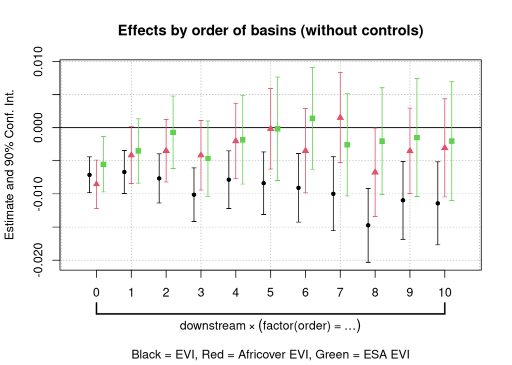

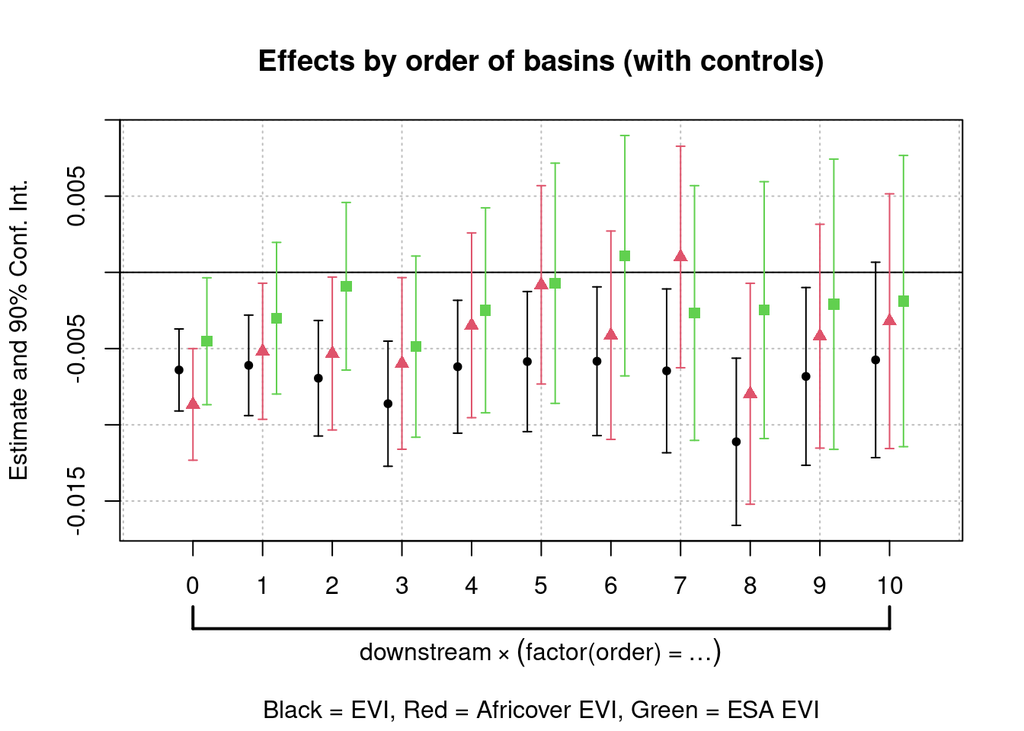

### Falsification Tests - Placebo Outcomes

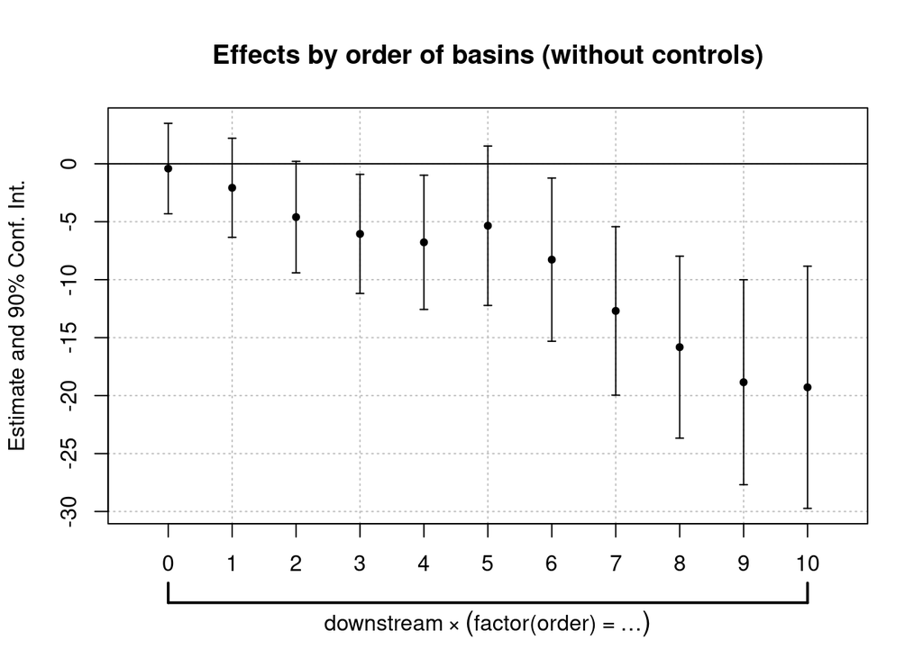

```
##                                 mod2_order_plot.1   mod2_order_plot.2
## Dependent Var.:                          tmp_mean             tmp_max
##
## downstream                      -0.0384. (0.0212)    -0.0219 (0.0277)
## distance                        -0.0021* (0.0008)   -0.0020. (0.0011)
## distance square                -9.69e-6 (7.04e-6)  -6.47e-6 (9.27e-6)
## elevation                    -0.0025*** (8.21e-5) -0.0020*** (0.0001)
## slope                            -0.0053 (0.0055) -0.0285*** (0.0075)
## soilgrid_groupedAlisols           0.0321 (0.0582)     0.0421 (0.0779)
## soilgrid_groupedAndosols           1.026 (0.7280)     0.7118 (0.6576)
## soilgrid_groupedArenosols         0.0440 (0.0292)    0.1031* (0.0416)
## soilgrid_groupedCalcisols      0.3075*** (0.0696)  0.6625*** (0.1070)
## soilgrid_groupedCambisols         0.0350 (0.0338)     0.0634 (0.0432)
## soilgrid_groupedFerralsols       -0.0201 (0.0279)     0.0079 (0.0299)
## soilgrid_groupedFluvisols         0.1266 (0.0790)     0.1011 (0.1024)
## soilgrid_groupedGleysols         -0.0508 (0.0367)    -0.0144 (0.0515)
## soilgrid_groupedHistosols      -0.3190** (0.1151)  -0.8433** (0.3125)
## soilgrid_groupedKastanozems       0.0177 (0.1175)    -0.5578 (0.3920)
## soilgrid_groupedLeptosols       -0.1338* (0.0643)    -0.0078 (0.0893)
## soilgrid_groupedLixisols         -0.0242 (0.0225)    -0.0190 (0.0277)
## soilgrid_groupedLuvisols         0.0649* (0.0276)  0.1880*** (0.0340)
## soilgrid_groupedNitisols          0.1147 (0.1110)    0.2744* (0.1260)
## soilgrid_groupedNodata            0.1711 (0.1629)     0.2581 (0.1761)
## soilgrid_groupedPhaeozems        -0.0896 (0.1124)   -0.7515* (0.3096)
## soilgrid_groupedPlanosols     -0.6876*** (0.1732) -0.5863*** (0.1473)
## soilgrid_groupedPlinthosols       0.0094 (0.0295)     0.0222 (0.0409)
## soilgrid_groupedPodzols          -0.0005 (0.0337)     0.0093 (0.0364)
## soilgrid_groupedRegosols        0.2790** (0.1027)   0.5452** (0.1674)
## soilgrid_groupedSolonchaks        0.1374 (0.1426)     0.2500 (0.1578)
## soilgrid_groupedSolonetz          0.2624 (0.3981)     0.4604 (0.4442)
## soilgrid_groupedVertisols     -0.1638*** (0.0466)  -0.1713** (0.0599)
## accessibility_to_cities_2015   0.0002** (5.59e-5)  0.0002** (6.93e-5)
## pop_2015                       -7.21e-8 (1.46e-7) -4.09e-7. (2.35e-7)
## downstream x distance           0.0030** (0.0010)    0.0029* (0.0013)
## downstream x I(distance^2)    2.23e-5** (8.37e-6)    1.52e-5 (1.1e-5)
## Fixed-Effects:               -------------------- -------------------
## year                                          Yes                 Yes
## as.factor(mine_basin)                         Yes                 Yes
## ____________________________ ____________________ ___________________
## S.E.: Clustered                      by: HYBAS_ID        by: HYBAS_ID
```

[output cut: 34 more lines]

```
## soilgrid_groupedVertisols     -0.2641*** (0.0574)     -21.35* (8.324)
## accessibility_to_cities_2015    5.24e-5 (5.98e-5) -0.0447*** (0.0053)
## pop_2015                        1.89e-7 (1.64e-7)   2.41e-5 (2.56e-5)
## downstream x distance            0.0024. (0.0013)  0.5119*** (0.1337)
## downstream x I(distance^2)    4.16e-5*** (1.1e-5)    -0.0005 (0.0011)
## Fixed-Effects:               -------------------- -------------------
## year                                          Yes                 Yes
## as.factor(mine_basin)                         Yes                 Yes
## ____________________________ ____________________ ___________________
## S.E.: Clustered                      by: HYBAS_ID        by: HYBAS_ID
## Observations                              114,496             114,496
## R2                                        0.98748             0.96248
## Within R2                                 0.27576             0.01654
## ---
## Signif. codes: 0 '***' 0.001 '**' 0.01 '*' 0.05 '.' 0.1 ' ' 1
```

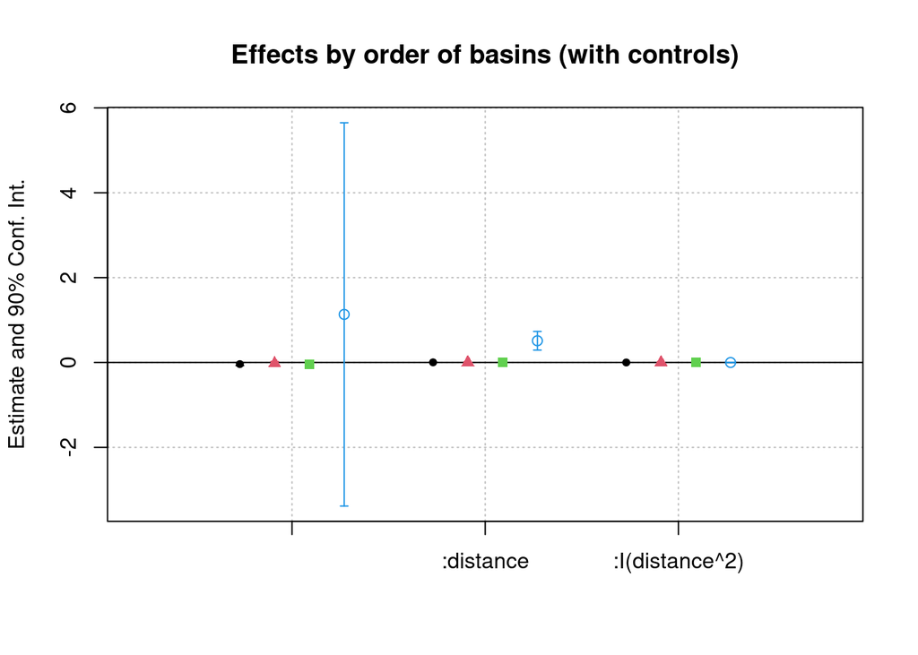